# META-ANALYSIS - NIS Dataset

Nina

July 2021

# 1 INTRODUCTION

This file describes the analysis of data from the **NIS** dataset. There are two other analysis files one for the **Eco-friendly dataset** and the other for the **General community**, including **Habitat-forming species**.

Here we read in the raw data that has been extracted from suitable studies (see the main body of the manuscript for the selection criteria). We then wrangle the data into a suitable format for constructing our models with **Metafor** (http://www.metafor-project.org/doku.php )

## 1.1 Setting up

```r
#Ensuring starting with a clean environment
rm(list=ls())
#turn off sci notation:
options (scipen = 999)

# ADDING OUTPUT DIRECTORY
# Will give warning if already exists
dir.create(file.path(getwd(), "outputs"))
dir.create(file.path(getwd(), "outputs/NIS"))


#Installing packages and loading existing ones.
# # If installations are necessary:
# install.packages("devtools")
# install.packages("tidyverse")
# install.packages("metafor")
# install.packages("patchwork")
# install.packages("R.rsp")
# devtools::install_github("itchyshin/orchard_plot", subdir = "orchaRd", force = TRUE, build_vignettes = TRUE)
#install.packages("downloadthis")


#libraries
# check conflicts.
library(rotl)
library(ape)
library(metafor)
library(orchaRd)
library(knitr)
library(broom)
library(clubSandwich)
library(multcomp)
library(kableExtra)
library(downloadthis)
library(tidyverse)
```

## 1.2 Loading and checking data file

```r
#import data
meta<-read.csv("./data/NIS_dataset.csv",header=T) #read in data

#changing many columns to factors/numeric:
meta<- meta %>% mutate_at (
  vars(
    Year,
    ReplicatesControl,
    ReplicatesTreatment,
    Totalindividuals),
  funs(as.numeric)) %>%
    mutate_at(
      vars(
        Study,
        Parameter,
        Species,
        Control,
        Control_detail,
        Control_detail_MOD,
        Treatment,
        Treatment_detail,
        Treatment_detail_MOD,
        Experiment),
    funs(as.factor)
    )


# showing data in .html version of doc
kable(meta, "html") %>%
  kable_styling("striped", position = "left") %>%
  scroll_box(width = "100%",
             height = "500px")
```

| Study | Year | Journal | Study.on.NIS. | MeanControl | upperSEControl | SEControl | SDControl | MeanTreatment | upperSETreatment | SETreatment | SDTreatment | ReplicatesControl | ReplicatesTreatment | Parameter | Group | FunctionalGroup | Species | Status.in.study.region | Status.in.study.region.source | Sizeoftilestandardisedperm2 | Sizeofassessedareatandardisedperm2 | Reportedmilligramsperm2 | Reporteddensityperm2 | Totalindividuals | Typeofmanipulation.Tile.Survey. | Movement | Orientation | Control | Treatment | … |
| --- | --- | --- | --- | --- | --- | --- | --- | --- | --- | --- | --- | --- | --- | --- | --- | --- | --- | --- | --- | --- | --- | --- | --- | --- | --- | --- | --- | --- | --- | --- |
| AndersonandUnderwood1994 | 1994 | Journal of Experimental Marine Biology and Ecology | N | 25.4854000 | 28.5437000 | 3.0583000 | 7.4912745 | 38.1553000 | 42.6699000 | 4.5146000 | 11.0584664 | 6 | 6 | Density | Invertebrates | Bryozoan | Watersipora arcuata | pest | publication | 0.0100 | 0.0100 | NA | 0.0100 | NA | Tile | fixed | downfacing | Wood | Concrete | … |
| AndersonandUnderwood1994 | 1994 | Journal of Experimental Marine Biology and Ecology | N | 25.4854000 | 28.5437000 | 3.0583000 | 7.4912745 | 16.3107000 | 19.2233000 | 2.9126000 | 7.1343838 | 6 | 6 | Density | Invertebrates | Bryozoan | Watersipora arcuata | pest | publication | 0.0100 | 0.0100 | NA | 0.0100 | NA | Tile | fixed | downfacing | Wood | Metal | … |
| AndersonandUnderwood1994 | 1994 | Journal of Experimental Marine Biology and Ecology | N | 25.4854000 | 28.5437000 | 3.0583000 | 7.4912745 | 14.7087000 | 17.7670000 | 3.0583000 | 7.4912745 | 6 | 6 | Density | Invertebrates | Bryozoan | Watersipora arcuata | pest | publication | 0.0100 | 0.0100 | NA | 0.0100 | NA | Tile | fixed | downfacing | Wood | Polymer | … |
| Chase2015 | 2015 | Thesis | Y | 0.4000000 | NA | 0.4000000 | 0.9797959 | 0.0000000 | NA | 0.0000000 | 0.0000000 | 6 | 6 | PercentageCover | Invertebrates | Ascidian | Diplosoma listerianum | introduced | publication | 0.0100 | 0.0064 | NA | NA | NA | Tile | floating | downfacing | Rock | Concrete | … |
| Chase2015 | 2015 | Thesis | Y | 0.4000000 | NA | 0.4000000 | 0.9797959 | 0.0000000 | NA | 0.0000000 | 0.0000000 | 6 | 6 | PercentageCover | Invertebrates | Ascidian | Diplosoma listerianum | introduced | publication | 0.0100 | 0.0064 | NA | NA | NA | Tile | floating | downfacing | Rock | Polymer | … |
| Chase2015 | 2015 | Thesis | Y | 0.4000000 | NA | 0.4000000 | 0.9797959 | 0.0000000 | NA | 0.0000000 | 0.0000000 | 6 | 6 | PercentageCover | Invertebrates | Ascidian | Diplosoma listerianum | introduced | publication | 0.0100 | 0.0064 | NA | NA | NA | Tile | floating | downfacing | Rock | Polymer | … |
| Chase2015 | 2015 | Thesis | Y | 1.0000000 | NA | 0.7745967 | 1.8973666 | 0.8000000 | NA | 0.3741657 | 0.9165151 | 6 | 6 | PercentageCover | Invertebrates | Ascidian | Diplosoma listerianum | introduced | publication | 0.0100 | 0.0064 | NA | NA | NA | Tile | floating | downfacing | Rock | Concrete | … |
| Chase2015 | 2015 | Thesis | Y | 1.0000000 | NA | 0.7745967 | 1.8973666 | 0.4000000 | NA | 0.2449490 | 0.6000000 | 6 | 6 | PercentageCover | Invertebrates | Ascidian | Diplosoma listerianum | introduced | publication | 0.0100 | 0.0064 | NA | NA | NA | Tile | floating | downfacing | Rock | Polymer | … |
| Chase2015 | 2015 | Thesis | Y | 1.0000000 | NA | 0.7745967 | 1.8973666 | 0.2000000 | NA | 0.2000000 | 0.4898979 | 6 | 6 | PercentageCover | Invertebrates | Ascidian | Diplosoma listerianum | introduced | publication | 0.0100 | 0.0064 | NA | NA | NA | Tile | floating | downfacing | Rock | Polymer | … |
| Chase2015 | 2015 | Thesis | Y | 12.2000000 | NA | 5.3422842 | 13.0858702 | 2.0000000 | NA | 1.5491933 | 3.7947332 | 6 | 6 | PercentageCover | Invertebrates | Ascidian | Diplosoma listerianum | introduced | publication | 0.0100 | 0.0064 | NA | NA | NA | Tile | floating | downfacing | Rock | Concrete | … |
| Chase2015 | 2015 | Thesis | Y | 12.2000000 | NA | 5.3422842 | 13.0858702 | 9.0000000 | NA | 5.4129474 | 13.2589592 | 6 | 6 | PercentageCover | Invertebrates | Ascidian | Diplosoma listerianum | introduced | publication | 0.0100 | 0.0064 | NA | NA | NA | Tile | floating | downfacing | Rock | Polymer | … |
| Chase2015 | 2015 | Thesis | Y | 12.2000000 | NA | 5.3422842 | 13.0858702 | 9.2000000 | NA | 3.7868193 | 9.2757749 | 6 | 6 | PercentageCover | Invertebrates | Ascidian | Diplosoma listerianum | introduced | publication | 0.0100 | 0.0064 | NA | NA | NA | Tile | floating | downfacing | Rock | Polymer | … |
| Chase2015 | 2015 | Thesis | Y | 33.2000000 | NA | 13.2529242 | 32.4629019 | 6.2000000 | NA | 2.1307276 | 5.2191954 | 6 | 6 | PercentageCover | Invertebrates | Ascidian | Diplosoma listerianum | introduced | publication | 0.0100 | 0.0064 | NA | NA | NA | Tile | floating | downfacing | Rock | Concrete | … |
| Chase2015 | 2015 | Thesis | Y | 33.2000000 | NA | 13.2529242 | 32.4629019 | 26.8000000 | NA | 10.6414285 | 26.0660699 | 6 | 6 | PercentageCover | Invertebrates | Ascidian | Diplosoma listerianum | introduced | publication | 0.0100 | 0.0064 | NA | NA | NA | Tile | floating | downfacing | Rock | Polymer | … |
| Chase2015 | 2015 | Thesis | Y | 33.2000000 | NA | 13.2529242 | 32.4629019 | 26.6000000 | NA | 10.5242577 | 25.7790613 | 6 | 6 | PercentageCover | Invertebrates | Ascidian | Diplosoma listerianum | introduced | publication | 0.0100 | 0.0064 | NA | NA | NA | Tile | floating | downfacing | Rock | Polymer | … |
| Chase2015 | 2015 | Thesis | Y | 35.6000000 | NA | 7.8076885 | 19.1248529 | 13.4000000 | NA | 3.8157568 | 9.3466572 | 6 | 6 | PercentageCover | Invertebrates | Ascidian | Diplosoma listerianum | introduced | publication | 0.0100 | 0.0064 | NA | NA | NA | Tile | floating | downfacing | Rock | Concrete | … |
| Chase2015 | 2015 | Thesis | Y | 35.6000000 | NA | 7.8076885 | 19.1248529 | 27.4000000 | NA | 5.5641711 | 13.6293800 | 6 | 6 | PercentageCover | Invertebrates | Ascidian | Diplosoma listerianum | introduced | publication | 0.0100 | 0.0064 | NA | NA | NA | Tile | floating | downfacing | Rock | Polymer | … |
| Chase2015 | 2015 | Thesis | Y | 35.6000000 | NA | 7.8076885 | 19.1248529 | 30.2000000 | NA | 7.8955684 | 19.3401138 | 6 | 6 | PercentageCover | Invertebrates | Ascidian | Diplosoma listerianum | introduced | publication | 0.0100 | 0.0064 | NA | NA | NA | Tile | floating | downfacing | Rock | Polymer | … |
| Chase2015 | 2015 | Thesis | Y | 0.0000000 | NA | 0.0000000 | 0.0000000 | 0.0000000 | NA | 0.0000000 | 0.0000000 | 6 | 6 | PercentageCover | Invertebrates | Ascidian | Botrylloides violaceus | introduced | publication | 0.0100 | 0.0064 | NA | NA | NA | Tile | floating | downfacing | Rock | Concrete | … |
| Chase2015 | 2015 | Thesis | Y | 0.0000000 | NA | 0.0000000 | 0.0000000 | 0.1666667 | NA | 0.1666667 | 0.4082483 | 6 | 6 | PercentageCover | Invertebrates | Ascidian | Botrylloides violaceus | introduced | publication | 0.0100 | 0.0064 | NA | NA | NA | Tile | floating | downfacing | Rock | Polymer | … |
| Chase2015 | 2015 | Thesis | Y | 0.0000000 | NA | 0.0000000 | 0.0000000 | 0.0000000 | NA | 0.0000000 | 0.0000000 | 6 | 6 | PercentageCover | Invertebrates | Ascidian | Botrylloides violaceus | introduced | publication | 0.0100 | 0.0064 | NA | NA | NA | Tile | floating | downfacing | Rock | Polymer | … |
| Chase2015 | 2015 | Thesis | Y | 0.4000000 | NA | NA | NA | 0.7000000 | NA | NA | NA | 6 | 6 | PercentageCover | Invertebrates | Ascidian | Botrylloides violaceus | introduced | publication | 0.0100 | 0.0064 | NA | NA | NA | Tile | floating | downfacing | Rock | Concrete | … |
| Chase2015 | 2015 | Thesis | Y | 0.4000000 | NA | NA | NA | 0.1833333 | NA | NA | NA | 6 | 6 | PercentageCover | Invertebrates | Ascidian | Botrylloides violaceus | introduced | publication | 0.0100 | 0.0064 | NA | NA | NA | Tile | floating | downfacing | Rock | Polymer | … |
| Chase2015 | 2015 | Thesis | Y | 0.4000000 | NA | NA | NA | 0.7000000 | NA | NA | NA | 6 | 6 | PercentageCover | Invertebrates | Ascidian | Botrylloides violaceus | introduced | publication | 0.0100 | 0.0064 | NA | NA | NA | Tile | floating | downfacing | Rock | Polymer | … |
| Chase2015 | 2015 | Thesis | Y | 0.8000000 | NA | 0.3741657 | 0.9165151 | 1.4000000 | NA | 0.9797959 | 2.4000000 | 6 | 6 | PercentageCover | Invertebrates | Ascidian | Botrylloides violaceus | introduced | publication | 0.0100 | 0.0064 | NA | NA | NA | Tile | floating | downfacing | Rock | Concrete | … |
| Chase2015 | 2015 | Thesis | Y | 0.8000000 | NA | 0.3741657 | 0.9165151 | 0.2000000 | NA | 0.2000000 | 0.4898979 | 6 | 6 | PercentageCover | Invertebrates | Ascidian | Botrylloides violaceus | introduced | publication | 0.0100 | 0.0064 | NA | NA | NA | Tile | floating | downfacing | Rock | Polymer | … |
| Chase2015 | 2015 | Thesis | Y | 0.8000000 | NA | 0.3741657 | 0.9165151 | 1.4000000 | NA | 0.9797959 | 2.4000000 | 6 | 6 | PercentageCover | Invertebrates | Ascidian | Botrylloides violaceus | introduced | publication | 0.0100 | 0.0064 | NA | NA | NA | Tile | floating | downfacing | Rock | Polymer | … |
| Chase2015 | 2015 | Thesis | Y | 0.2000000 | NA | 0.2000000 | 0.4898979 | 5.2000000 | NA | 1.3564660 | 3.3226496 | 6 | 6 | PercentageCover | Invertebrates | Ascidian | Botrylloides violaceus | introduced | publication | 0.0100 | 0.0064 | NA | NA | NA | Tile | floating | downfacing | Rock | Concrete | … |
| Chase2015 | 2015 | Thesis | Y | 0.2000000 | NA | 0.2000000 | 0.4898979 | 0.8000000 | NA | 0.5830952 | 1.4282857 | 6 | 6 | PercentageCover | Invertebrates | Ascidian | Botrylloides violaceus | introduced | publication | 0.0100 | 0.0064 | NA | NA | NA | Tile | floating | downfacing | Rock | Polymer | … |
| Chase2015 | 2015 | Thesis | Y | 0.2000000 | NA | 0.2000000 | 0.4898979 | 0.6000000 | NA | 0.4000000 | 0.9797959 | 6 | 6 | PercentageCover | Invertebrates | Ascidian | Botrylloides violaceus | introduced | publication | 0.0100 | 0.0064 | NA | NA | NA | Tile | floating | downfacing | Rock | Polymer | … |

[output cut: 552 more lines]

```r
# this is the data we want to make available:
meta %>%
  download_this(
    output_name = "NIS_dataset",
    output_extension = ".csv",
    button_type = "default",
    has_icon = T,
    icon = "fa fa-save",
    csv2 = F
  )
```

## 1.3 Creating Reference Columns

Checking that there are sufficient identifier and reference columns for our random effects:

- Adding **Effect ID** which represents each unique datapoint in the database.
- **Study** already exists - showing data points which come from the same study.
- We also add **experiment ID**, which shows which datapoints come from the same experiment. We do this by grouping by study, location, and other reference columns that identify unique experiments within the same study.
- Duration is not included as we are incorporating repeated measures time points
- and therefore is not a unique identifier for experiment ID.

These are mostly important for the random effects and independence components of the analysis.

```r
# create column with unique data points.. row names essentially
meta <- rowid_to_column(meta, "Effect_ID")
meta$Effect_ID <- as.factor(meta$Effect_ID)

#need an ID to define experiment groupings
Exp_ID <- meta %>%
  group_by(Study,
           Experiment) %>%
  summarise(num_instances = n())

# row ID for exp number
Exp_ID <- rowid_to_column(Exp_ID, "Exp_ID")
# now join back to main dataset based based on this number:
meta <- left_join(meta,
                  Exp_ID,
                  by = c("Study",
                         "Experiment"))
meta$Exp_ID <- as.factor(meta$Exp_ID)

rm(Exp_ID) # leaving in for now, to check numbers

meta$ControlTreatment <-
  paste(meta$Control, meta$Treatment, sep = "_")
```

##Change proportion and density per day to density

```r
### Changing Proportions and Density per Day into density
#Change proportion to density first
change_these <-
  c("Effect_ID",
    "MeanControl",
    "SDControl",
    "MeanTreatment",
    "SDTreatment")

proportion_change <- meta %>%
  filter(Parameter == "Proportion") %>%
  mutate_at(vars(c(
    "SDControl", "SDTreatment", "MeanControl", "MeanTreatment"
  )),
  ~ . / 100 * Totalindividuals) %>%
  select(all_of(change_these))

proportion_change_test <- meta %>%
  filter(Parameter == "Proportion") %>%
  select(all_of(change_these))

#compare
aa <-
  left_join (proportion_change_test, proportion_change, by = "Effect_ID")

#final version
meta_big <- left_join (meta, proportion_change, by = "Effect_ID")

names_x <-
  c("SDControl.x",
    "SDTreatment.x",
    "MeanControl.x",
    "MeanTreatment.x")
names_y <-
  c("SDControl.y",
    "SDTreatment.y",
    "MeanControl.y",
    "MeanTreatment.y")

meta <- meta_big %>%
  mutate(SDControl.y = ifelse(is.na(SDControl.y), SDControl.x, SDControl.y)) %>%
  mutate(MeanControl.y = ifelse(is.na(MeanControl.y), MeanControl.x, MeanControl.y)) %>%
  mutate(SDTreatment.y = ifelse(is.na(SDTreatment.y), SDTreatment.x, SDTreatment.y)) %>%
  mutate(MeanTreatment.y = ifelse(is.na(MeanTreatment.y), MeanTreatment.x, MeanTreatment.y)) %>%
  select(-ends_with(".x")) %>%
  rename_at(vars(names_y), ~ str_sub(., end = -3))

#then rename proportion into density to standardise per area
levels(meta$Parameter)[levels(meta$Parameter) == "Proportion"] <-
  "Density"



#Density per day -> calculate density for experimental period (as reported per square meter no need to standardise)
density_change2 <- meta %>%
  filter(Parameter == "DensityPerDay") %>%
  mutate(Durationdays) %>%
  mutate_at(vars(c(
    "SDControl", "SDTreatment", "MeanControl", "MeanTreatment"
  )),
  ~ . * Durationdays) %>%
  select(all_of(change_these))

density_change_test2 <- meta %>%
  filter(Parameter == "DensityPerDay") %>%
  select(all_of(change_these))

#compare
bb <-
  left_join (density_change_test2, density_change2, by = "Effect_ID")

#final version
meta_big <- left_join (meta, density_change2, by = "Effect_ID")


names_x <-
  c("SDControl.x",
    "SDTreatment.x",
    "MeanControl.x",
    "MeanTreatment.x")
names_y <-
  c("SDControl.y",
    "SDTreatment.y",
    "MeanControl.y",
    "MeanTreatment.y")


meta <- meta_big %>%
  mutate(SDControl.y = ifelse(is.na(SDControl.y), SDControl.x, SDControl.y)) %>%
  mutate(MeanControl.y = ifelse(is.na(MeanControl.y), MeanControl.x, MeanControl.y)) %>%
  mutate(SDTreatment.y = ifelse(is.na(SDTreatment.y), SDTreatment.x, SDTreatment.y)) %>%
  mutate(MeanTreatment.y = ifelse(is.na(MeanTreatment.y), MeanTreatment.x, MeanTreatment.y)) %>%
  select(-ends_with(".x")) %>%
  rename_at(vars(names_y), ~ str_sub(., end = -3))

#then rename proportion into density to standardise per area
levels(meta$Parameter)[levels(meta$Parameter) == "DensityPerDay"] <-
  "Density"

#dropping parameter levels not present anymore
meta <- meta %>% droplevels()
```

##Definitions:

**Parameter:** these are

```
## [1] "Density"         "PercentageCover"
```

**FunctionalGroup:** not included as this dataset contains sessile species only

**Control:** these are substrates that are considered NATURAL and have not undergone a transformative process:

```r
levels(meta$Control)
```

```
## [1] "Biogenic" "Rock"     "Wood"
```

And the detailed breakdown of included natural materials: Biogenic (details)

```r
meta %>%
  dplyr::filter(Control == "Biogenic") %>%
  {    unique(.$Control_detail)  }
```

```
## [1] Crassostrea virginica Perna viridis         Mytella charruana
## [4] Oyster_CV             Oyster_CA             Shell
## 13 Levels: Crassostrea virginica Granite Marble Mytella charruana ... Wood
```

Rock (details)

```r
meta %>%
  dplyr::filter(Control == "Rock") %>%
  {    unique(.$Control_detail)  }
```

```
## [1] Granite   Rock      Sandstone Marble    Slate
## 13 Levels: Crassostrea virginica Granite Marble Mytella charruana ... Wood
```

Wood (details)

```r
meta %>%
  dplyr::filter(Control == "Wood") %>%
  {    unique(.$Control_detail)  }
```

```
## [1] Plywood Wood
## 13 Levels: Crassostrea virginica Granite Marble Mytella charruana ... Wood
```

**Treatment:** these are substrates that are considered ARTIFICIAL and are either completely manufactured or have undergone a some kind of transformative process:

```r
levels(meta$Treatment)
```

```
## [1] "Clay"     "Concrete" "Metal"    "Polymer"
```

Detailed breakdown of included artificial materials:

Clay (details)

```r
meta %>%
  dplyr::filter(Treatment =="Clay") %>%
  { unique(.$Treatment_detail) }
```

```
## [1] Ceramic
## 16 Levels: Acrylic Aluminium Cement Ceramic Concrete Fibreglass HDPE PC ... Styrofoam
```

Concrete (details)

```r
meta %>%
  dplyr::filter(Treatment =="Concrete") %>%
  { unique(.$Treatment_detail) }
```

```
## [1] Concrete Cement
## 16 Levels: Acrylic Aluminium Cement Ceramic Concrete Fibreglass HDPE PC ... Styrofoam
```

Metal (details)

```r
meta %>%
  dplyr::filter(Treatment =="Metal") %>%
  { unique(.$Treatment_detail) }
```

```
## [1] Aluminium       Steel           Stainless Steel
## 16 Levels: Acrylic Aluminium Cement Ceramic Concrete Fibreglass HDPE PC ... Styrofoam
```

Polymer (details)

```r
meta %>%
  dplyr::filter(Treatment =="Polymer") %>%
  { unique(.$Treatment_detail) }
```

```
##  [1] Fibreglass HDPE       PVC        Plexiglass Acrylic    PP
##  [7] PET        PC         Styrofoam  Rubber
## 16 Levels: Acrylic Aluminium Cement Ceramic Concrete Fibreglass HDPE PC ... Styrofoam
```

# 2 DATA WRANGLING

## 2.1 Dealing with zeros

The method we’re using for ESCALC - the log ratio of means, cannot handle zeros in the denominator/numerator as you can’t take a log of zero.

To deal with zeros we can either, run the model:

- with the zeros removed, or
- with the zero values having 0.5 added to them.

We prefer to keep the data - rather than just remove the zeros - as the means or SDs of controls and treatments that contain zeros, make up ~27% of the data.

Here we add a constant of 0.5 to SDs of control and treatment, and means of control and treatment.

```r
#first lets see how many zeros there are:
meta_zeros <- meta %>%
  filter(MeanControl == 0.0 |
           MeanTreatment == 0.0 | SDControl == 0.0 | SDTreatment == 0.0)
# 155 rows with zeros in means or SDs

# Removing Zeros - this works, but not used
# meta_no_zeros <- meta[meta$MeanControl != 0, ]
# meta_no_zeros <- meta_no_zeros[meta_no_zeros$MeanTreatment != 0, ]
# meta_no_zeros <- meta_no_zeros[meta_no_zeros$SDControl != 0, ]
# meta_no_zeros <- meta_no_zeros[meta_no_zeros$SDTreatment != 0, ]
# 427 from 582 - removed 155

#meta <- meta_no_zeros  # the option for just removing all rows with zeros.

# there are 155 instances in total of 582 possibles.
# this is 26.63% - we'd prefer to retain the data and therefore add 0.5 to everything.

meta_05 <- meta %>%
  mutate_at(vars(c(
    "SDControl", "SDTreatment", "MeanControl", "MeanTreatment"
  )),
  ~ . + 0.5)
#using the 0.5 option..(leaves in Nas)
meta <- meta_05
rm(meta_05, meta_zeros) #clearing variables no longer needed.

# check output
#head(meta)
```

## 2.2 Dropping or replacing SD blanks

Previously we left blank SDs out, but this also removed a lot of data. A better practice is to use the function of the log of the SD and the control or treatment means to replace the missing data.

Checks: How many studies/datapoints have missing SDs?

```r
#datapoints with missing SDs:
meta_gaps <- meta %>% filter(is.na(SDControl) & is.na(SDTreatment))
#using only complete pairs for developing the function
meta_no_gaps <-
  meta %>% filter(!is.na(SDControl) & !is.na(SDTreatment))
```

There are **31** datapoints missing SDs out of **582** in the full dataset. This equates to **5.3264605** % of datapoints.

There are **3** studies with gaps in SDs from a total of **11** studies in the dataset. This equates to **27.2727273**%. Less than ~20-30% is considered OK.

The studies with missing SDs are:

```
##   unique(meta_gaps$Study)
## 1               Chase2015
## 2              Maetal2017
## 3                 Urh2017
```

The distribution of missing SD is as follows:

```
##
##         Density PercentageCover
##              19              12
```

```
##
##         Density PercentageCover
##             207             375
```

```
##
##         Density PercentageCover
##        9.178744        3.200000
```

```r
#removing levels of parameters not present anymore
meta_gaps<- meta_gaps %>% droplevels()
meta_no_gaps<- meta_no_gaps %>% droplevels()
```

The parameters that at missing SDs include: **Density, PercentageCover**, (both of them).

```r
# showing data in .html version of doc
kable(a, "html") %>%
  kable_styling("striped", position = "left") %>%
  scroll_box(width = "100%",
             height = "100%")
```

| names | Density | PercentageCover |
| --- | --- | --- |
| No. datapoints missing SD | 19.000000 | 12.0 |
| Total no. datapoints | 207.000000 | 375.0 |
| Percentage datapoints missing SD | 9.178744 | 3.2 |

```r
rm(a)
```

Filling in the missing SDs for both the controls and the treatments, separately: ### Control:

```r
#Origninal data
# plot(x,y)
plot(meta_no_gaps$MeanControl, meta_no_gaps$SDControl)
```

```r
#Logged data
# plotting trend lines per parameter and overall trend line.
p05 <-
  ggplot(meta_no_gaps, aes(x = log10(MeanControl) , y = log10(SDControl))) +
  geom_point(aes(colour = Parameter)) +
  stat_smooth (method = "lm", aes (colour = Parameter), se = F) +
  stat_smooth(method = "lm", aes(), se = F)
ggsave(filename = "./outputs/NIS/control_mean_sd.tiff")

# find the equation of the line:
#lm(y~x)
#must log10 the data as with the plot.
reg_2_05 <-
  lm(log10(meta_no_gaps$SDControl) ~ log10(meta_no_gaps$MeanControl))
# check this against the plot
plot(log10(meta_no_gaps$MeanControl),
     log10(meta_no_gaps$SDControl))
abline(reg_2_05, col = "blue")
```

```r
#model results summary
coef(reg_2_05)
paste('log10(SD) =',
      coef(reg_2_05)[[2]],
      '* log10(mean)',
      '+',
      coef(reg_2_05)[[1]])

# using the results from the lm() to "predict" or fill the gaps in the original
#data frame:
meta <- meta %>%
  mutate(SDControl = ifelse(is.na(SDControl),
                            10 ^ ((
                              coef(reg_2_05)[[2]] * log10(MeanControl)
                            ) +
                              coef(reg_2_05)[[1]]), SDControl))
# comparative plots
#no gaps
meta_no_gaps %>%
  ggplot(aes(x = MeanControl, y = SDControl)) +
  geom_point()
```

```r
ggsave(filename = "./outputs/NIS/Control_original.tiff")
#gaps
meta %>%
  ggplot(aes(x = MeanControl, y = SDControl)) +
  geom_point()
```

```r
ggsave(filename = "./outputs/NIS/Control_filled.tiff")

# comparative plots - logged
#no gaps logged
meta_no_gaps %>%
  ggplot(aes(x = log10(MeanControl), y = log10(SDControl))) +
  geom_point()
```

```r
ggsave(filename = "./outputs/NIS/Control_original_log.tiff")


rm(p05)
```

Filled Gaps:

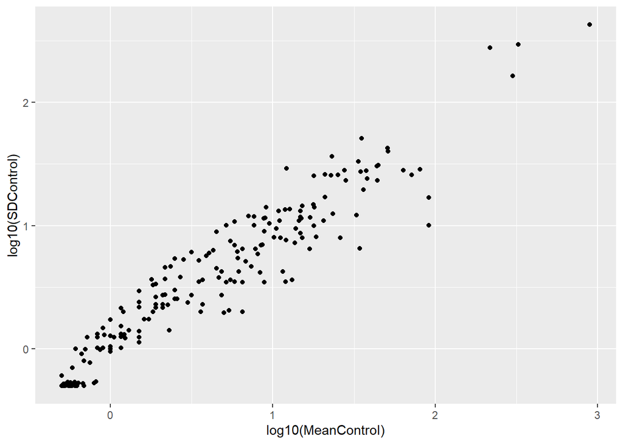

```r
#gaps logged
meta %>%
  ggplot(aes(x = log10(MeanControl), y = log10(SDControl))) +
  geom_point()
```

```r
ggsave(filename = "./outputs/NIS/Control_filled_log.tiff")
```

### 2.2.1 Treatment:

```r
#Origninal data
# plot(x,y)
plot(meta_no_gaps$MeanTreatment, meta_no_gaps$SDTreatment)
```

```r
#Logged data
# plotting trend lines per parameter and overall trend line.
meta_no_gaps %>%
  ggplot(aes(x = log10(MeanTreatment) , y = log10(SDTreatment))) +
  geom_point(aes(colour = Parameter)) +
  stat_smooth (method = "lm", aes (colour = Parameter), se = F) +
  stat_smooth(method = "lm", aes(), se = F)
```

```r
ggsave(filename = "./outputs/NIS/Treatment_mean_sd.tiff")
# some outliers - but mostly looks ok.

# find the equation of the line:
#lm(y~x)
reg_3_05 <-
  lm(log10(meta_no_gaps$SDTreatment) ~ log10(meta_no_gaps$MeanTreatment))
plot(log10(meta_no_gaps$MeanTreatment),
     log10(meta_no_gaps$SDTreatment))
abline(reg_3_05, col = "blue")
```

```r
#model results summary
coef(reg_3_05)
paste('log10(SD) =',
      coef(reg_3_05)[[2]],
      '* log10(mean)',
      '+',
      coef(reg_3_05)[[1]])

#filling gaps in TREATMENT SD:
meta <- meta %>%
  mutate(SDTreatment = ifelse(is.na(SDTreatment),
                              10 ^ ((
                                coef(reg_3_05)[[2]] * log10(MeanTreatment)
                              ) +
                                coef(reg_3_05)[[1]]), SDTreatment))
#Checking changes by plotting
#comparative plots
#no gaps
meta_no_gaps %>%
  ggplot(aes(x = MeanTreatment, y = SDTreatment)) +
  geom_point()
```

```r
ggsave(filename = "./outputs/NIS/Treatment_original.tiff")
#gaps
meta %>%
  ggplot(aes(x = MeanTreatment, y = SDTreatment)) +
  geom_point()
```

```r
ggsave(filename = "./outputs/NIS/Treatment_filled.tiff")

# comparative plots - logged
#no gaps logged
meta_no_gaps %>%
  ggplot(aes(x = log10(MeanTreatment), y = log10(SDTreatment))) +
  geom_point()
```

```r
ggsave(filename = "./outputs/NIS/Treatment_original_log.tiff")
```

Filled Gaps:

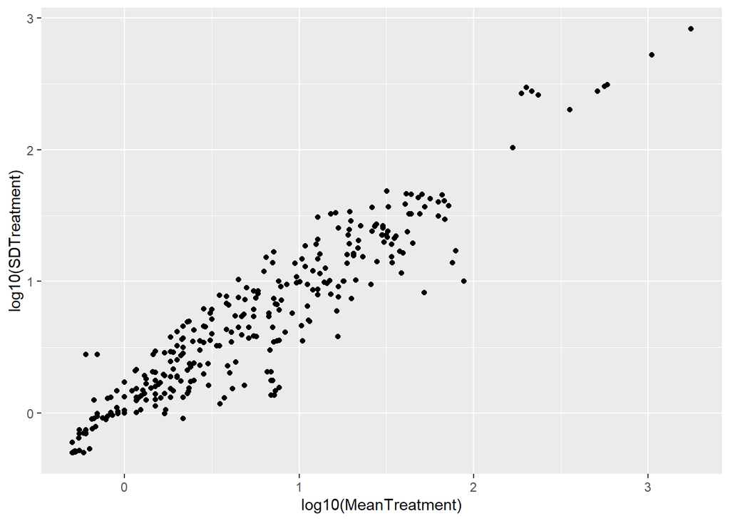

```r
#gaps logged
meta %>%
  ggplot(aes(x = log10(MeanTreatment), y = log10(SDTreatment))) +
  geom_point()
```

```r
ggsave(filename = "./outputs/NIS/Treatment_filled_log.tiff")
```

Filled gaps for all **CONTROL/Natural** materials

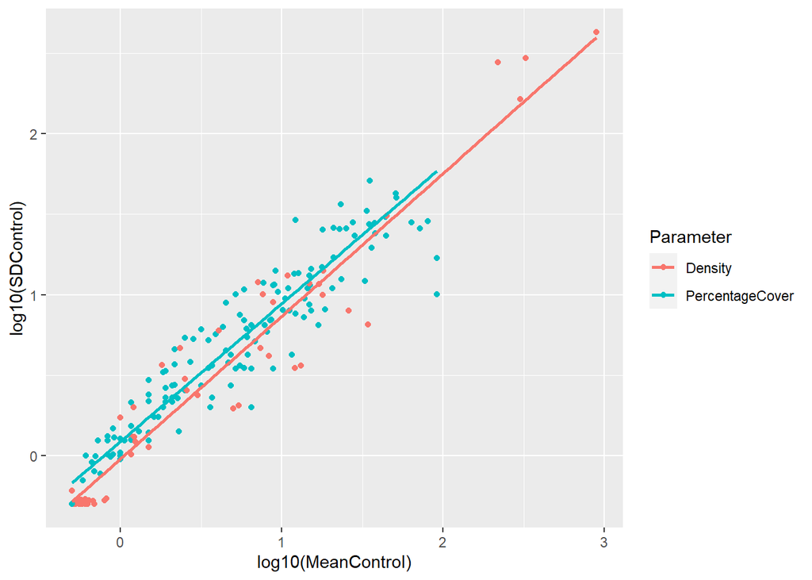

```r
p <-
  ggplot(meta, aes(x = log10(MeanControl) , y = log10(SDControl), )) +
  geom_point(aes(colour = Parameter))
p + stat_smooth (method = "lm", aes (colour = Parameter), se = F)
```

Filled gaps for all **TREATMENT/Artificial** materials

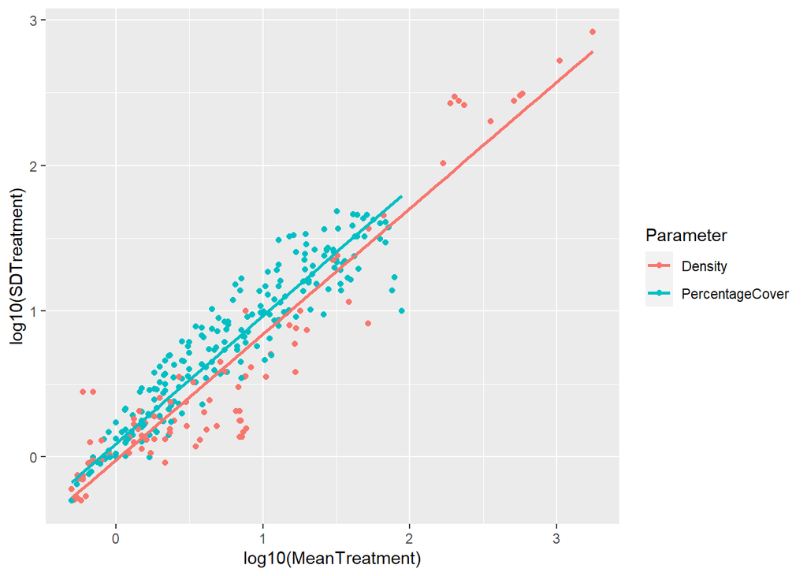

```r
p <-
  ggplot(meta, aes(x = log10(MeanTreatment) , y = log10(SDTreatment), )) +
  geom_point(aes(colour = Parameter))
p + stat_smooth (method = "lm", aes (colour = Parameter), se = F)
```

## 2.3 Removing excess variables

```r
rm(reg_2_05,reg_3_05,meta_gaps,meta_no_gaps,p)
```

##Studies per Exp_ID to check for sufficient replication -> make reduced datasets otherwise

For later in the code, these levels with less than 3 data points need to be dropped.

```r
#checking how many studies are in each level:
Treatment_levels<-levels(meta$Treatment)
Treatment_ExpID<- map(Treatment_levels, ~length(unique(meta$Exp_ID[meta$Treatment ==.])))

Control_levels<-levels(meta$Control)
Control_ExpID<- map(Control_levels, ~length(unique(meta$Exp_ID[meta$Control ==.])))

#Clay has insufficient replication-> make reduced dataset for models with moderators
meta_reduced <- subset(meta, Treatment!="Clay")
meta_reduced<- meta_reduced %>% droplevels()

#checking how many studies are in each level:
ControlTreatment_levels<-levels(meta_reduced$ControlTreatment)
ControlTreatment_ExpID<- map(ControlTreatment_levels, ~length(unique(meta_reduced$Exp_ID[meta_reduced$ControlTreatment ==.])))
```

## 2.4 Accounting for non-independence

Partitioning the “n”

Accounting for instances where the experimental error is shared between datapoints rather than being independent is an important step. This is because the meta-regression models we’re using assume independence, unless told otherwise.

Here we partition the replicates of the controls and treatments depending on whether they are shared or not.

- when grouped by control.. how many treatment TYPES are there? (ie cases of shared treatments)
- when grouped by treatment.. how many control TYPES are there? (ie cases of shared controls)

Partitioning based on Control:

```r
#Adding in a new column to the dataset for the reduced controls per treatment

meta <- meta %>%
  group_by(Exp_ID) %>%
  mutate(unique_types = n_distinct(Treatment_detail))

# Partition the N based on these results:
meta <- meta %>%
  mutate(reducedReplicatesControl = (ReplicatesControl / unique_types))



meta_reduced <- meta_reduced %>%
  group_by(Exp_ID) %>%
  mutate(unique_types = n_distinct(Treatment_detail))

# Partition the N based on these results:
meta_reduced <- meta_reduced %>%
  mutate(reducedReplicatesControl = (ReplicatesControl / unique_types))
```

Partitioning based on Treatment:

```r
#Adding in a new column to the dataset for the reduced replicates per control

meta <- meta %>%
  group_by(Exp_ID) %>%
  mutate(unique_types = n_distinct(Control_detail))

# Partition the N based on these results:
meta <- meta %>%
  mutate(reducedReplicatesTreatment = (ReplicatesTreatment / unique_types))


meta_reduced <- meta_reduced %>%
  group_by(Exp_ID) %>%
  mutate(unique_types = n_distinct(Control_detail))

# Partition the N based on these results:
meta_reduced <- meta_reduced %>%
  mutate(reducedReplicatesTreatment = (ReplicatesTreatment / unique_types))
```

# 3 ESCALC AND VCV

Have now switched Control and Treatment to ensure the Orchard plot is still inline with the standard meta plots. This means we now have:

Group 1 = TREATMENT - Artificial substrates Group 2 = CONTROL - Natural substrates (Therefore +ve results favour treatments, and -ve results favour control)

Calculating the effect sizes and outcome measures. We’re using the Risk Ratio - in the form of Ratio of Means, and we will take the log of this ratio - centered around zero.

```r
# Escalc funtion:
# meta <-  escalc(
#           m1i = meta$MeanTreatment,
#           sd1i = meta$SDTreatment,
#           n1i = meta$ReplicatesTreatment,
#           m2i = meta$MeanControl,
#           sd2i = meta$SDControl,
#           n2i = meta$reducedReplicatesControl,
#           measure = "ROM",
#           append = TRUE,
#           data = meta
#         )

lnRR <- function(CMean, CSD, CN, EMean, ESD, EN){
yi<-log( EMean / CMean)
vi <- CSD^2 / (CN * CMean^2) + ESD^2 / (EN * EMean^2)
print(data.frame(yi,vi))
}

meta.lnRR <- lnRR(
  CMean = meta$MeanControl,
  CSD = meta$SDControl,
  CN = meta$reducedReplicatesControl,
  EMean = meta$MeanTreatment,
  ESD = meta$SDTreatment,
  EN = meta$reducedReplicatesTreatment)

meta<- cbind(meta, meta.lnRR)

meta_reduced.lnRR <- lnRR(
  CMean = meta_reduced$MeanControl,
  CSD = meta_reduced$SDControl,
  CN = meta_reduced$reducedReplicatesControl,
  EMean = meta_reduced$MeanTreatment,
  ESD = meta_reduced$SDTreatment,
  EN = meta_reduced$reducedReplicatesTreatment)

meta_reduced<- cbind(meta_reduced, meta_reduced.lnRR)
```

# 4 VCV MATRICES

To account for multiple timepoints coming from the same tile/experiment this calculates a matrix which is used as “V” in the models that follow. For the models the “Yi” comes from Escalc, and the “VI” will come from this V.

This VCV matrix uses **Study** as a clustering parameter, which will then account for all non-independence in the experiments within study - in this case that includes, repeated measures sampling **AND** multiple measures from the same experiment (measurement parameters). [which is only a problem for the “All” models].

```r
V <-
  impute_covariance_matrix(
    vi = meta$vi,
    cluster = meta$Study,
    r = 0.5,
    return_list = F
  )


#This is just a test of the vcv functionality.
# The vcv is calculated for each model or group at the modelling stage.
V.check <-
  impute_covariance_matrix(
    vi = meta$vi,
    cluster = meta$Study,
    r = 0.5,
    return_list = F
  )

# using the return_list = F option is not recommended when the elements aren't
# ordered... which could cause issues, there's a check to see that they are correct.

#all.equal(meta$vi, diag(V.check))


V_reduced <-
  impute_covariance_matrix(
    vi = meta_reduced$vi,
    cluster = meta_reduced$Study,
    r = 0.5,
    return_list = F
  )


#This is just a test of the vcv functionality.
# The vcv is calculated for each model or group at the modelling stage.
V_reduced.check <-
  impute_covariance_matrix(
    vi = meta_reduced$vi,
    cluster = meta_reduced$Study,
    r = 0.5,
    return_list = F
  )

# using the return_list = F option is not recommended when the elements aren't
# ordered... which could cause issues, there's a check to see that they are correct.

#all.equal(meta_reduced$vi, diag(V_reduced.check))
```

# 5 PHYLOGENETIC TREE

Created phylogenetic tree from the rotl package examples and using the tree of life database: https://tree.opentreeoflife.org

```r
unique(meta$Species)
```

```
##  [1] Watersipora arcuata      Diplosoma listerianum    Botrylloides violaceus
##  [4] Membranipora membranacea Didemnum vexillum        Tubastraea coccinea
##  [7] Tubastraea tagusensis    Perna viridis            Mytella strigata
## [10] Conopeum seurati         Cryptosula pallasiana    Watersipora subtorquata
## [13] Schizoporella errata     Botrylloides leachii     Botryllus schlosseri
## [16] Ciona intestinalis       Hydroides elegans        Bugula flabellata
## [19] Bugula neritina          Crassostrea ariakensis   Ascidiella aspersa
## 21 Levels: Ascidiella aspersa Botrylloides leachii ... Watersipora subtorquata
```

```r
#correct names-M. senile does not exist, as unsure which one of the two M. senile to pick, so M. dianthus (one node above) was chosen
meta$Species <-
  gsub("Metridium senile", "Metridium dianthus", meta$Species)
meta$Species <- as.factor(meta$Species)

a <- unique(meta$Species)
a <- as.character(a)
a
```

```
##  [1] "Watersipora arcuata"      "Diplosoma listerianum"
##  [3] "Botrylloides violaceus"   "Membranipora membranacea"
##  [5] "Didemnum vexillum"        "Tubastraea coccinea"
##  [7] "Tubastraea tagusensis"    "Perna viridis"
##  [9] "Mytella strigata"         "Conopeum seurati"
## [11] "Cryptosula pallasiana"    "Watersipora subtorquata"
## [13] "Schizoporella errata"     "Botrylloides leachii"
## [15] "Botryllus schlosseri"     "Ciona intestinalis"
## [17] "Hydroides elegans"        "Bugula flabellata"
## [19] "Bugula neritina"          "Crassostrea ariakensis"
## [21] "Ascidiella aspersa"
```

```r
##need internet connection for this part
taxa <- tnrs_match_names(names = a)


tree <- tol_induced_subtree(ott_ids = ott_id(taxa))
```

```r
#remove ott ids to match the species ids
tree$tip.label <-
  strip_ott_ids(tree$tip.label, remove_underscores = TRUE)

#plot tree
plot(tree,
     cex = .8,
     label.offset = .1,
     no.margin = TRUE)

tree <- compute.brlen(tree)
cor <- vcv(tree, cor = T)
cor #to see the correlations
```

```
##                          Ascidiella aspersa Ciona intestinalis
## Ascidiella aspersa                     1.00               0.95
## Ciona intestinalis                     0.95               1.00
## Diplosoma listerianum                  0.85               0.85
## Didemnum vexillum                      0.85               0.85
## Botryllus schlosseri                   0.70               0.70
## Botrylloides leachii                   0.70               0.70
## Botrylloides violaceus                 0.70               0.70
## Watersipora subtorquata                0.10               0.10
## Watersipora arcuata                    0.10               0.10
## Bugula neritina                        0.10               0.10
## Bugula flabellata                      0.10               0.10
## Schizoporella errata                   0.10               0.10
## Cryptosula pallasiana                  0.10               0.10
## Conopeum seurati                       0.10               0.10
## Membranipora membranacea               0.10               0.10
## Crassostrea ariakensis                 0.10               0.10
## Perna viridis                          0.10               0.10
## Mytella strigata                       0.10               0.10
## Hydroides elegans                      0.10               0.10
## Tubastraea coccinea                    0.00               0.00
## Tubastraea tagusensis                  0.00               0.00
##                          Diplosoma listerianum Didemnum vexillum
## Ascidiella aspersa                        0.85              0.85
## Ciona intestinalis                        0.85              0.85
## Diplosoma listerianum                     1.00              0.95
## Didemnum vexillum                         0.95              1.00
## Botryllus schlosseri                      0.70              0.70
## Botrylloides leachii                      0.70              0.70
## Botrylloides violaceus                    0.70              0.70
## Watersipora subtorquata                   0.10              0.10
## Watersipora arcuata                       0.10              0.10
## Bugula neritina                           0.10              0.10
## Bugula flabellata                         0.10              0.10
## Schizoporella errata                      0.10              0.10
## Cryptosula pallasiana                     0.10              0.10
## Conopeum seurati                          0.10              0.10
## Membranipora membranacea                  0.10              0.10
## Crassostrea ariakensis                    0.10              0.10
## Perna viridis                             0.10              0.10
```

[output cut: 165 more lines]

```
## Botrylloides violaceus                    0.00
## Watersipora subtorquata                   0.00
## Watersipora arcuata                       0.00
## Bugula neritina                           0.00
## Bugula flabellata                         0.00
## Schizoporella errata                      0.00
## Cryptosula pallasiana                     0.00
## Conopeum seurati                          0.00
## Membranipora membranacea                  0.00
## Crassostrea ariakensis                    0.00
## Perna viridis                             0.00
## Mytella strigata                          0.00
## Hydroides elegans                         0.00
## Tubastraea coccinea                       0.95
## Tubastraea tagusensis                     1.00
```

```r
# adding phylogeny
meta$Phylogeny <- meta$Species



#for reduced dataset
unique(meta_reduced$Species)
```

```
##  [1] Watersipora arcuata      Diplosoma listerianum    Botrylloides violaceus
##  [4] Membranipora membranacea Didemnum vexillum        Tubastraea coccinea
##  [7] Tubastraea tagusensis    Perna viridis            Mytella strigata
## [10] Conopeum seurati         Cryptosula pallasiana    Watersipora subtorquata
## [13] Schizoporella errata     Botrylloides leachii     Botryllus schlosseri
## [16] Ciona intestinalis       Hydroides elegans        Bugula flabellata
## [19] Bugula neritina          Crassostrea ariakensis   Ascidiella aspersa
## 21 Levels: Ascidiella aspersa Botrylloides leachii ... Watersipora subtorquata
```

```r
#correct names-M. senile does not exist, as unsure which one of the two M. senile to pick, I chose M. dianthus (one node above)
meta_reduced$Species <-
  gsub("Metridium senile", "Metridium dianthus", meta_reduced$Species)
meta_reduced$Species <- as.factor(meta_reduced$Species)

b <- unique(meta_reduced$Species)
b <- as.character(b)
b
```

```
##  [1] "Watersipora arcuata"      "Diplosoma listerianum"
##  [3] "Botrylloides violaceus"   "Membranipora membranacea"
##  [5] "Didemnum vexillum"        "Tubastraea coccinea"
##  [7] "Tubastraea tagusensis"    "Perna viridis"
##  [9] "Mytella strigata"         "Conopeum seurati"
## [11] "Cryptosula pallasiana"    "Watersipora subtorquata"
## [13] "Schizoporella errata"     "Botrylloides leachii"
## [15] "Botryllus schlosseri"     "Ciona intestinalis"
## [17] "Hydroides elegans"        "Bugula flabellata"
## [19] "Bugula neritina"          "Crassostrea ariakensis"
## [21] "Ascidiella aspersa"
```

```r
##need internet connection for this part
taxa2 <- tnrs_match_names(names = b)


tree2 <- tol_induced_subtree(ott_ids = ott_id(taxa2))
```

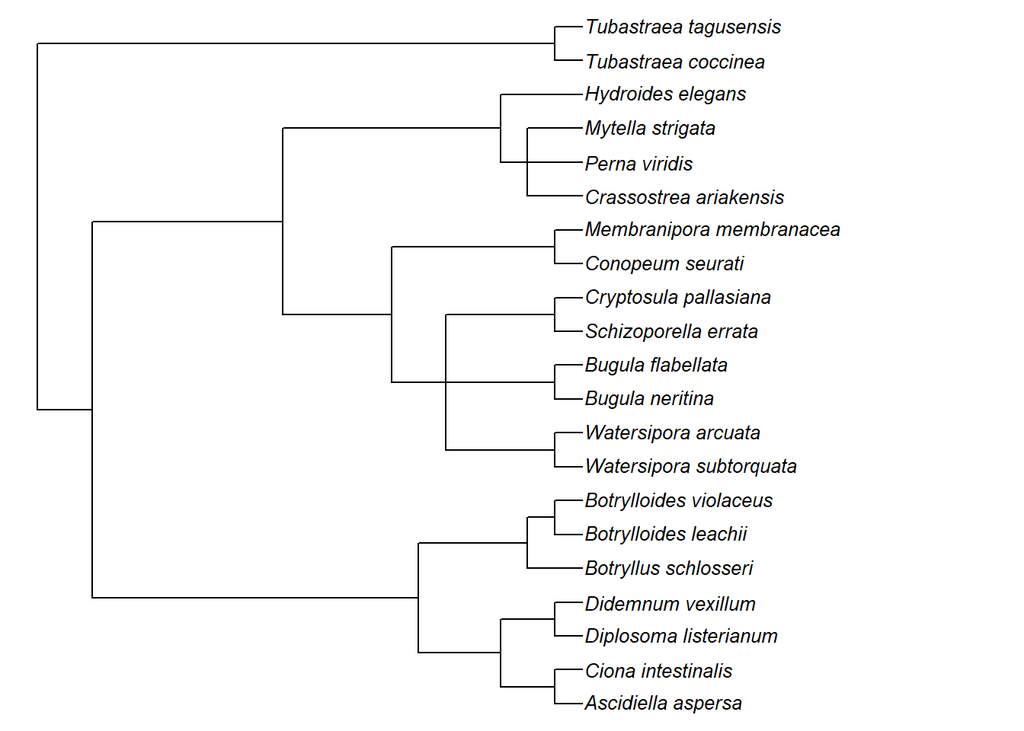

```r
#remove ott ids to match the species ids
tree2$tip.label <-
  strip_ott_ids(tree2$tip.label, remove_underscores = TRUE)

#plot tree
plot(tree2,
     cex = .8,
     label.offset = .1,
     no.margin = TRUE)
```

```r
tree2 <- compute.brlen(tree2)
cor2 <- vcv(tree2, cor2 = T)
cor2 #to see the correlations
```

```
##                          Ascidiella aspersa Ciona intestinalis
## Ascidiella aspersa                     1.00               0.95
## Ciona intestinalis                     0.95               1.00
## Diplosoma listerianum                  0.85               0.85
## Didemnum vexillum                      0.85               0.85
## Botryllus schlosseri                   0.70               0.70
## Botrylloides leachii                   0.70               0.70
## Botrylloides violaceus                 0.70               0.70
## Watersipora subtorquata                0.10               0.10
## Watersipora arcuata                    0.10               0.10
## Bugula neritina                        0.10               0.10
## Bugula flabellata                      0.10               0.10
## Schizoporella errata                   0.10               0.10
## Cryptosula pallasiana                  0.10               0.10
## Conopeum seurati                       0.10               0.10
## Membranipora membranacea               0.10               0.10
## Crassostrea ariakensis                 0.10               0.10
## Perna viridis                          0.10               0.10
## Mytella strigata                       0.10               0.10
## Hydroides elegans                      0.10               0.10
## Tubastraea coccinea                    0.00               0.00
## Tubastraea tagusensis                  0.00               0.00
##                          Diplosoma listerianum Didemnum vexillum
## Ascidiella aspersa                        0.85              0.85
## Ciona intestinalis                        0.85              0.85
## Diplosoma listerianum                     1.00              0.95
## Didemnum vexillum                         0.95              1.00
## Botryllus schlosseri                      0.70              0.70
## Botrylloides leachii                      0.70              0.70
## Botrylloides violaceus                    0.70              0.70
## Watersipora subtorquata                   0.10              0.10
## Watersipora arcuata                       0.10              0.10
## Bugula neritina                           0.10              0.10
## Bugula flabellata                         0.10              0.10
## Schizoporella errata                      0.10              0.10
## Cryptosula pallasiana                     0.10              0.10
## Conopeum seurati                          0.10              0.10
## Membranipora membranacea                  0.10              0.10
## Crassostrea ariakensis                    0.10              0.10
## Perna viridis                             0.10              0.10
```

[output cut: 165 more lines]

```
## Botrylloides violaceus                    0.00
## Watersipora subtorquata                   0.00
## Watersipora arcuata                       0.00
## Bugula neritina                           0.00
## Bugula flabellata                         0.00
## Schizoporella errata                      0.00
## Cryptosula pallasiana                     0.00
## Conopeum seurati                          0.00
## Membranipora membranacea                  0.00
## Crassostrea ariakensis                    0.00
## Perna viridis                             0.00
## Mytella strigata                          0.00
## Hydroides elegans                         0.00
## Tubastraea coccinea                       0.95
## Tubastraea tagusensis                     1.00
```

```r
# adding phylogeny
meta_reduced$Phylogeny <- meta_reduced$Species
```

# 6 MODELS

Now we add the models in a stepwise facshion

The overarching method followed is:

1. Run the most simple version of the model. Without moderators (but with random effects) Check the heterogeniety: a significant amount of heterogeneity means that although you may have a main trend in your effect size, there is STILL a lot of unexplained variability in the effect size . Heterogeneity is generally caused by the different ways in which studies are undertaken. There is a rule of thumb to use a as a threshold for when to continue/stop (>60% is moderate, >70% is high).
2. Add moderators to your model - do this one by one and in each case you can check the effect on the heterogeneity. Showing that the variability of the main effect was moderated by.. The moderators could be useful predictors of the variability in the effect of natural vs artificial substrates on the diversity/growth/cover..
3. Finally add all moderators and random effects into one model and the amount of heterogeneity remaining should NOT be significant. This also serves to check the robustness of the moderators.

SIMPLE MODEL

Steps:

- simple model, then add treatment, then control, then durations all separately
- in each case calculate the I2, then the R2 (model fit).
- Then plot an orchard plot - precision shown by size of ‘fruit’.
- Then plot a caterpillar plot - mean effect size plus CIs for each study
- Both plots have 95% confidence intervals that support the mean effect size, as well as prediction intervals which predict the range of effects that may be observed.

Setting dpi value for plots (lower number to speed up script)

```r
plot_dpi <- 300
#suggestions: 320 - retina, 300 - print, 72 - screen
```

## 6.1 Simple model

```r
rom.simple <- rma.mv(
  yi,
  V,
  random = list(
    ~ 1 | Study,
    ~ 1 | Exp_ID,
    ~ 1 | Effect_ID,
    ~ 1 | Parameter,
    ~ 1 | Species,
    ~ 1 | Phylogeny
  ),
  R = list(Phylogeny = cor),
  method = "REML",
  data = meta,
  control = list(optimizer = "optim")
)


sum <- summary(rom.simple)
sum_I2 <- i2_ml(rom.simple, method = "ns")
sum_R2 <- r2_ml(rom.simple)

res.simple <-
  data.frame(
    effectname = attr(sum$beta, "dimnames")[[1]],
    beta = as.numeric(sum$beta),
    percentage_increase_or_decrease_on_Artificial = (exp(sum$beta)-1)*100,
    real.effect.value_exp_beta = exp(sum$beta),
    pval = sum$pval,
    ci.lb = sum$ci.lb,
    ci.ub = sum$ci.ub,
    I2_total = sum_I2[[1]] * 100,
    I2_study = sum_I2[[2]] * 100,
    I2_Exp_ID = sum_I2[[3]] * 100,
    I2_Effect_ID = sum_I2[[4]] * 100,
    I2_Parameter = sum_I2[[5]] * 100,
    I2_Species = sum_I2[[6]] * 100,
    I2_Phylogeny = sum_I2[[7]] * 100,
    R2_marginal_fixed = sum_R2[[1]] * 100,
    R2_conditional_fixed_random = sum_R2[[2]] * 100,
    AIC = rom.simple$fit.stats$REML[3]
  )

res_simple_df <- bind_rows(res.simple)
write.csv(res_simple_df, file = "./outputs/NIS/summ_simple.csv")

# show as kable table:
res_simple_df %>%
  kable("html", digits = 3) %>%
  kable_styling("striped", position = "left") %>%
  scroll_box(width = "100%",
             height = "100%")
```

|  | effectname | beta | percentage_increase_or_decrease_on_Artificial | real.effect.value_exp_beta | pval | ci.lb | ci.ub | I2_total | I2_study | I2_Exp_ID | I2_Effect_ID | I2_Parameter | I2_Species | I2_Phylogeny | R2_marginal_fixed | R2_conditional_fixed_random | AIC |
| --- | --- | --- | --- | --- | --- | --- | --- | --- | --- | --- | --- | --- | --- | --- | --- | --- | --- |
| intrcpt | intrcpt | 0.148 | 15.981 | 1.16 | 0.364 | -0.172 | 0.468 | 74.592 | 0.001 | 48.461 | 24.913 | 0 | 1.217 | 0 | 0 | 100 | 1515.597 |

```r
simp_orch <-
  orchard_plot(rom.simple, mod = "Int", xlab = "Ratio of means") +
  scale_y_discrete(labels = c("Intrcpt" = "Overall")) +
  theme(
    text = element_text(size = 20, colour = "black"),
    axis.text.y = element_text(size = 20, colour = "black")
  ) +
  theme(
    legend.direction = "horizontal",
    legend.title = element_text(size = 20, colour = "black"),
    legend.text = element_text(size = 20, colour = "black")
  )

ggsave(
  simp_orch,
  file = "./outputs/NIS/simp_orch.tiff",
  dpi = plot_dpi,
  width = 8,
  height = 8
)
ggsave(
  simp_orch,
  file = "./outputs/NIS/simp_orch.pdf",
  dpi = plot_dpi,
  width = 8,
  height = 8
)


simp_cat <-
  caterpillars(rom.simple, mod = "Int", xlab = "Ratio of means")
ggsave(simp_cat, file = "./outputs/NIS/simp_cat.tiff", dpi = plot_dpi)
```

## 6.2 Adding Mod; TREATMENT_DETAIL_MOD

To check relative influence of each TREATMENT material. Most sub-levels showed similar trends and justified being grouped as either: metal, polymer, clay or concrete.

```r
#using reduced dataset where each level comprises of at least 3 experiments
rom.Treatment_detail_mod <-
  rma.mv(
    yi,
    V,
    mods = ~ Treatment_detail_MOD  - 1,
    random = list(
      ~ 1 | Study,
      ~ 1 |
        Exp_ID,
      ~ 1 |
        Effect_ID,
      ~ 1 |
        Parameter,
      ~ 1 |
        Species,
      ~ 1 |
        Phylogeny
    ),
    R = list(Phylogeny = cor),
    method = "REML",
    data = meta,
    control = list(optimizer =
                     "optim")
  )


sum_detail_mod <- summary(rom.Treatment_detail_mod)

g_col <- c("grey","grey","grey","grey","grey","grey","grey","grey","grey")

Treatment_orch_detail_mod <-
  orchard_plot(rom.Treatment_detail_mod, mod = "Treatment_detail_MOD", xlab = "Ratio of means") + scale_fill_manual(values = g_col) + scale_colour_manual(values = g_col) + theme(axis.text.y = element_text(angle = 0, hjust = 1))

ggsave(
  Treatment_orch_detail_mod,
  file = "./outputs/NIS/Treatment_orch_detail_mod.tiff",
  dpi = plot_dpi,
  width = 10,
  height = 8
)
```

Plots with treatment detail included:

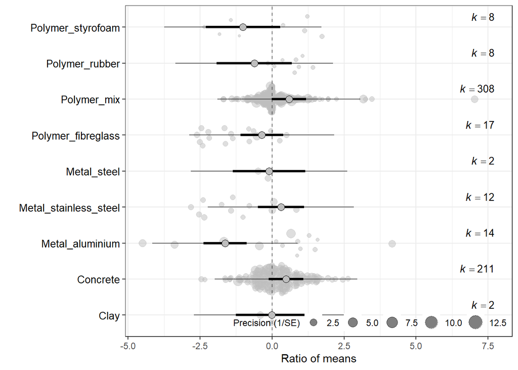

```r
Treatment_orch_detail_mod
```

## 6.3 Adding Mod; CONTROL_DETAIL_MOD

To check relative influence of each CONTROL material. Most sub-levels showed similar trends and justified being grouped as either: rock, wood or biogenic.

```r
#using reduced dataset where each level comprises of at least 3 experiments
rom.Control_detail_mod <-
  rma.mv(
    yi,
    V,
    mods = ~ Control_detail_MOD  - 1,
    random = list(
      ~ 1 | Study,
      ~ 1 |
        Exp_ID,
      ~ 1 |
        Effect_ID,
      ~ 1 |
        Parameter,
      ~ 1 |
        Species,
      ~ 1 |
        Phylogeny
    ),
    R = list(Phylogeny = cor),
    method = "REML",
    data = meta,
    control = list(optimizer =
                     "optim")
  )


sum_detail_mod <- summary(rom.Control_detail_mod)

g_col <- c("grey","grey","grey","grey","grey","grey","grey","grey","grey","grey")

Control_orch_detail_mod <-
  orchard_plot(rom.Control_detail_mod, mod = "Control_detail_MOD", xlab = "Ratio of means") + scale_fill_manual(values = g_col) + scale_colour_manual(values = g_col) + theme(axis.text.y = element_text(angle = 0, hjust = 1))

ggsave(
  Control_orch_detail_mod,
  file = "./outputs/NIS/Control_orch_detail_mod.tiff",
  dpi = plot_dpi,
  width = 10,
  height = 8
)
```

Plots with control detail included:

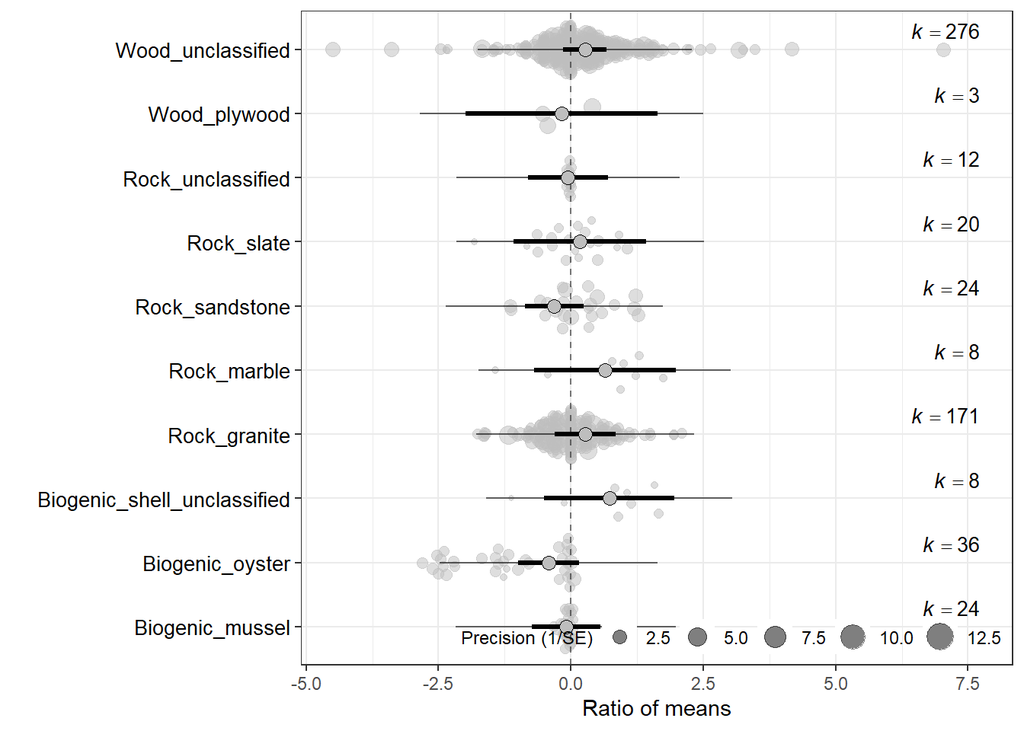

```r
Control_orch_detail_mod
```

## 6.4 Adding Mod INTERACTION: Control:Treatment

Testing to see whether the interaction between control and treatment materials is a significant moderator.

```r
#using reduced dataset where each level comprises of at least 3 experiments
rom.ControlTreatment <-
  rma.mv(
    yi,
    V_reduced,
    mods = ~ ControlTreatment - 1,
    random = list(
      ~ 1 | Study,
      ~ 1 |
        Exp_ID,
      ~ 1 |
        Effect_ID,
      ~ 1 |
        Parameter,
      ~ 1 |
        Species,
      ~ 1 |
        Phylogeny
    ),
    R = list(Phylogeny = cor2),
    method = "REML",
    data = meta_reduced,
    control = list(optimizer =
                     "optim")
  )


sum <- summary(rom.ControlTreatment)
sum_I2 <- i2_ml(rom.ControlTreatment, method = "ns")
sum_R2 <- r2_ml(rom.ControlTreatment)

res.ControlTreatment <-
  data.frame(
    effectname = attr(sum$beta, "dimnames")[[1]],
    beta = as.numeric(sum$beta),
    percentage_increase_or_decrease_on_Artificial = (exp(sum$beta)-1)*100,
    real.effect.value_exp_beta = exp(sum$beta),
    pval = sum$pval,
    ci.lb = sum$ci.lb,
    ci.ub = sum$ci.ub,
    I2_total = sum_I2[[1]] * 100,
    I2_study = sum_I2[[2]] * 100,
    I2_Exp_ID = sum_I2[[3]] * 100,
    I2_Effect_ID = sum_I2[[4]] * 100,
    I2_Parameter = sum_I2[[5]] * 100,
    I2_Species = sum_I2[[6]] * 100,
    I2_Phylogeny = sum_I2[[7]] * 100,
    R2_marginal_fixed = sum_R2[[1]] * 100,
    R2_conditional_fixed_random = sum_R2[[2]] * 100,
    Moderator_significance_stat = sum$QM,
    Moderator_significance_pval = sum$QMp,
    AIC = rom.ControlTreatment$fit.stats$REML[3]
  )


res_ControlTreatment_df <- bind_rows(res.ControlTreatment)
write.csv(res_ControlTreatment_df, file = "./outputs/NIS/summ_ControlTreatment.csv")


ControlTreatment_orch <-
  orchard_plot(rom.ControlTreatment, mod = "ControlTreatment", xlab = "Ratio of means") + theme(axis.text.y = element_text(angle = 0, hjust = 1))

ggsave(
  ControlTreatment_orch,
  file = "./outputs/NIS/ControlTreatment_orch.tiff",
  dpi = plot_dpi,
  width = 10,
  height = 8
)

#12 levels
g_col <- c("grey","grey","grey","grey","grey","grey","grey","grey","grey","grey","grey","grey")

ControlTreatment_orch_grey <-
  orchard_plot(rom.ControlTreatment, mod = "ControlTreatment", xlab = "Ratio of means") + scale_fill_manual(values = g_col) + scale_colour_manual(values = g_col) + theme(axis.text.y = element_text(hjust = 0.95, angle=0)) +
  ggtitle("Non-indigenous species") +
  theme(plot.title = element_text(size = 14, face = "bold"),
        text = element_text(size = 12),
        axis.text.y = element_text(size = 12))


ControlTreatment_orch_grey
```

```r
ggsave(
  ControlTreatment_orch_grey,
  file = "./outputs/NIS/ControlTreatment_orch_grey.tiff",
  dpi = plot_dpi,
  width = 10,
  height = 8
)


ControlTreatment_cat <-
  caterpillars(rom.ControlTreatment, mod = "ControlTreatment", xlab = "Ratio of means")
ggsave(ControlTreatment_cat, file = "./outputs/NIS/ControlTreatment_cat.tiff", dpi = plot_dpi)


# checking contrasts:

table(meta_reduced$ControlTreatment)
contrast_ControlTreatment <- summary(glht(
  rom.ControlTreatment,
  linfct = c(
    #Biogenic - only Biogenic-Polymer so no contrast
    # Rock
    "ControlTreatmentRock_Metal - ControlTreatmentRock_Polymer = 0",
    "ControlTreatmentRock_Concrete - ControlTreatmentRock_Polymer = 0",
    "ControlTreatmentRock_Concrete - ControlTreatmentRock_Metal = 0",
    # Wood
    "ControlTreatmentWood_Concrete - ControlTreatmentWood_Polymer = 0",
    "ControlTreatmentWood_Metal - ControlTreatmentWood_Polymer = 0",
    "ControlTreatmentWood_Concrete - ControlTreatmentWood_Metal = 0",
    # Concrete
    "ControlTreatmentRock_Concrete - ControlTreatmentWood_Concrete = 0",
    # Metal
    "ControlTreatmentRock_Metal - ControlTreatmentWood_Metal = 0",
    "ControlTreatmentRock_Metal - ControlTreatmentBiogenic_Metal = 0",
    "ControlTreatmentWood_Metal - ControlTreatmentBiogenic_Metal = 0",
    # POlymer
    "ControlTreatmentBiogenic_Polymer - ControlTreatmentRock_Polymer = 0",
    "ControlTreatmentRock_Polymer - ControlTreatmentWood_Polymer = 0",
    "ControlTreatmentBiogenic_Polymer - ControlTreatmentWood_Polymer = 0"
  )
))

contrasts_list <- mget(ls(pattern = "^contrast_+"))
summary(contrasts_list)

con_df <- map_df(contrasts_list, ~ broom::tidy(.x), .id = "names")

#save
write.csv(con_df, file = "./outputs/NIS/contrasts.csv")
```

Summary of results:

```r
res.ControlTreatment %>%
  kable("html", digits = 3) %>%
  kable_styling("striped", position = "left") %>%
  scroll_box(width = "100%",
             height = "100%")
```

|  | effectname | beta | percentage_increase_or_decrease_on_Artificial | real.effect.value_exp_beta | pval | ci.lb | ci.ub | I2_total | I2_study | I2_Exp_ID | I2_Effect_ID | I2_Parameter | I2_Species | I2_Phylogeny | R2_marginal_fixed | R2_conditional_fixed_random | Moderator_significance_stat | Moderator_significance_pval | AIC |
| --- | --- | --- | --- | --- | --- | --- | --- | --- | --- | --- | --- | --- | --- | --- | --- | --- | --- | --- | --- |
| ControlTreatmentBiogenic_Metal | ControlTreatmentBiogenic_Metal | 0.027 | 2.784 | 1.028 | 0.945 | -0.749 | 0.804 | 79.485 | 19.563 | 44.677 | 13.748 | 0.403 | 1.09 | 0.004 | 7.859 | 99.996 | 85.975 | 0 | 1443.776 |
| ControlTreatmentBiogenic_Polymer | ControlTreatmentBiogenic_Polymer | 0.031 | 3.186 | 1.032 | 0.921 | -0.590 | 0.653 | 79.485 | 19.563 | 44.677 | 13.748 | 0.403 | 1.09 | 0.004 | 7.859 | 99.996 | 85.975 | 0 | 1443.776 |
| ControlTreatmentRock_Concrete | ControlTreatmentRock_Concrete | 0.139 | 14.946 | 1.149 | 0.635 | -0.436 | 0.715 | 79.485 | 19.563 | 44.677 | 13.748 | 0.403 | 1.09 | 0.004 | 7.859 | 99.996 | 85.975 | 0 | 1443.776 |
| ControlTreatmentRock_Metal | ControlTreatmentRock_Metal | 0.459 | 58.294 | 1.583 | 0.267 | -0.351 | 1.269 | 79.485 | 19.563 | 44.677 | 13.748 | 0.403 | 1.09 | 0.004 | 7.859 | 99.996 | 85.975 | 0 | 1443.776 |
| ControlTreatmentRock_Polymer | ControlTreatmentRock_Polymer | 0.314 | 36.947 | 1.369 | 0.291 | -0.269 | 0.898 | 79.485 | 19.563 | 44.677 | 13.748 | 0.403 | 1.09 | 0.004 | 7.859 | 99.996 | 85.975 | 0 | 1443.776 |
| ControlTreatmentWood_Concrete | ControlTreatmentWood_Concrete | 0.624 | 86.629 | 1.866 | 0.030 | 0.061 | 1.187 | 79.485 | 19.563 | 44.677 | 13.748 | 0.403 | 1.09 | 0.004 | 7.859 | 99.996 | 85.975 | 0 | 1443.776 |
| ControlTreatmentWood_Metal | ControlTreatmentWood_Metal | -1.707 | -81.860 | 0.181 | 0.000 | -2.442 | -0.972 | 79.485 | 19.563 | 44.677 | 13.748 | 0.403 | 1.09 | 0.004 | 7.859 | 99.996 | 85.975 | 0 | 1443.776 |
| ControlTreatmentWood_Polymer | ControlTreatmentWood_Polymer | 0.624 | 86.578 | 1.866 | 0.029 | 0.063 | 1.184 | 79.485 | 19.563 | 44.677 | 13.748 | 0.403 | 1.09 | 0.004 | 7.859 | 99.996 | 85.975 | 0 | 1443.776 |

Plot for Interaction

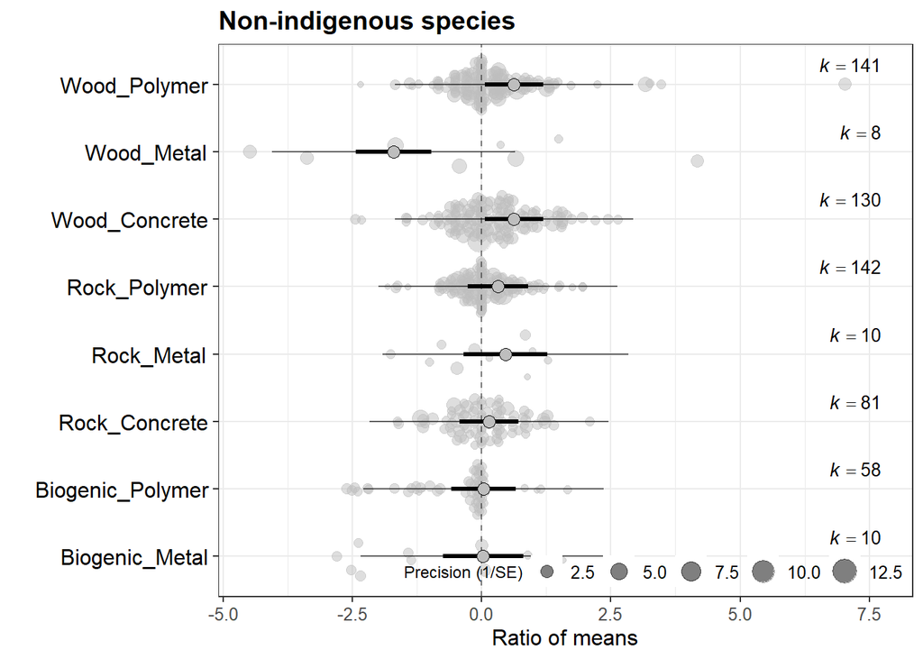

```r
ControlTreatment_orch_grey
```

```r
  # theme(text = element_text(size = 15),
  #       axis.text.y = element_text(size = 15))
```

## 6.5 Adding Mod DURATION

[figure not shown]

```r
# DURATION CONTIN NEEDS TRANSFORMED.. BEST IS SQRT
#Log Duraation has zeros.. therefore PLUS 1 first
#checking the transform:
# qqnorm(meta$Durationmonths)
# qqline(meta$Durationmonths)
# qqnorm(sqrt(meta$Durationmonths)) #best
# qqline(sqrt(meta$Durationmonths)) #best
# qqnorm(log10(meta$Durationmonths))
# qqline(log10(meta$Durationmonths))
# qqnorm(log10(meta$Durationmonths+1))
# qqline(log10(meta$Durationmonths+1))

#model with duration as a continuous moderator
rom.Duration <- rma.mv(
  yi,
  V,
  mods = ~ sqrt(Durationmonths),
  random = list(
    ~ 1 | Study,
    ~ 1 | Exp_ID,
    ~ 1 | Effect_ID,
    ~ 1 | Parameter,
    ~ 1 | Species,
    ~ 1 | Phylogeny
  ),
  R = list(Phylogeny = cor),
  method = "REML",
  data = meta,
  control = list(optimizer = "optim")
)


forest(rom.Duration)
```

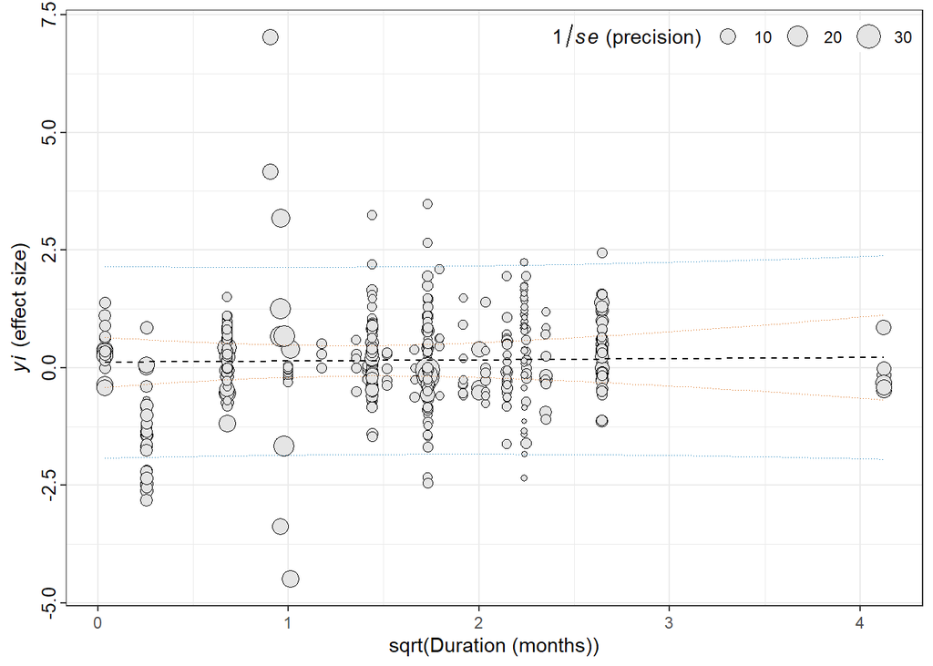

```r
summary(rom.Duration)

sum <- summary(rom.Duration)
sum_I2 <- i2_ml(rom.Duration, method = "ns")
sum_R2 <- r2_ml(rom.Duration)

res.Duration <-
  data.frame(
    effectname = attr(sum$beta, "dimnames")[[1]],
    beta = as.numeric(sum$beta),
    percentage_increase_or_decrease_on_Artificial = (exp(sum$beta)-1)*100,
    real.effect.value_exp_beta = exp(sum$beta),
    pval = sum$pval,
    ci.lb = sum$ci.lb,
    ci.ub = sum$ci.ub,
    I2_total = sum_I2[[1]] * 100,
    I2_study = sum_I2[[2]] * 100,
    I2_Exp_ID = sum_I2[[3]] * 100,
    I2_Effect_ID = sum_I2[[4]] * 100,
    I2_Parameter = sum_I2[[5]] * 100,
    I2_Species = sum_I2[[6]] * 100,
    I2_Phylogeny = sum_I2[[7]] * 100,
    R2_marginal_fixed = sum_R2[[1]] * 100,
    R2_conditional_fixed_random = sum_R2[[2]] * 100,
    Moderator_significance_stat = sum$QM,
    Moderator_significance_pval = sum$QMp,
    AIC = rom.Duration$fit.stats$REML[3]
  )

res_Duration_df <- bind_rows(res.Duration)
write.csv(res_Duration_df, file = "./outputs/NIS/summ_Duration.csv")




#####
## PLot of Duration - Bubble plot
#####

#A scatter plot of log duration and effect size.
#Using the predict.rma function, which requires a model (rma.mv)
# Examples from:
# Hayward et al 2021. DOI: 10.1111/ele.13757. A broadscale analysis of host-symbiont
# cophylogeny reveals the drivers of phylogenetic congruence

# to get the precision on this plot, ie 1/SE.. we need SE.. and for SE we need N.
# SE is then sqrt(var/N)

# We have separate N's for the control and the treatment, they are partitioned.
#SO first we need to work out the highest N in each case, and use that as the
# Total N.

meta$Replicates <-
  pmax(meta$ReplicatesTreatment, meta$ReplicatesControl)

pred_Durationmonths <- predict.rma(rom.Duration)

# plotting

fig_Durationmonths <-  meta %>%
  filter(!is.na(Durationmonths))  %>% # getting ride of NA values
  data.frame(
    .,
    ymin = pred_Durationmonths$ci.lb,
    ymax = pred_Durationmonths$ci.ub,
    ymin2 = pred_Durationmonths$cr.lb,
    ymax2 = pred_Durationmonths$cr.ub,
    pred = pred_Durationmonths$pred
  ) %>%
  ggplot(aes(
    x = sqrt(Durationmonths),
    y = yi,
    #yi = effect size
    size = 1 / sqrt(vi / Replicates),
    # precision: 1/SE /was (1 / yi) + 3 - which doesn't make sense.
    # we can use sample size N (ie number of replicates)

  )) +
  geom_point(shape = 21, fill = "grey90") +
  #geom_ribbon(aes(ymin = ymin, ymax = ymax), fill = "#0072B2")  + # not quite sure why this does not work
  geom_smooth(
    aes(y = ymin2),
    method =  "loess",
    se = FALSE,
    lty =  "dotted",
    lwd = 0.25,
    colour = "#0072B2"
  ) +
  geom_smooth(
    aes(y = ymax2),
    method =  "loess",
    se = FALSE,
    lty = "dotted",
    lwd = 0.25,
    colour = "#0072B2"
  ) +
  geom_smooth(
    aes(y = ymin),
    method =  "loess",
    se = FALSE,
    lty = "dotted",
    lwd = 0.25,
    colour = "#D55E00"
  ) +
  geom_smooth(
    aes(y = ymax),
    method =  "loess",
    se = FALSE,
    lty = "dotted",
    lwd = 0.25,
    colour = "#D55E00"
  ) +
  geom_smooth(
    aes(y = pred),
    method =  "loess",
    se = FALSE,
    lty = "dashed",
    lwd = 0.5,
    colour = "black"
  ) +
  #ylim(-1, 2) + xlim(-0.05, 2) +
  #geom_abline(intercept = mr_Duration..months.$beta[[1]], slope = mr_Duration..months.$beta[[2]], alpha = 0.7, linetype = "dashed", size = 0.5) +
  labs(x = "sqrt(Duration (months))",
       y = expression(paste(italic(yi), " (effect size)")),
       size = expression(paste(italic(1 / se), " (precision)"))) +
  guides(fill = "none", colour = "none") +
  # themes
  theme_bw() +
  theme(legend.position = c(1, 1),
        legend.justification = c(1, 1)) +
  theme(legend.direction = "horizontal") +
  #theme(legend.background = element_rect(fill = "white", colour = "black")) +
  theme(legend.background = element_blank()) +
  theme(axis.text.y = element_text(
    size = 10,
    colour = "black",
    hjust = 0.5,
    angle = 90
  ))

fig_Durationmonths
```

```r
ggsave(filename = "./outputs/NIS/Bubble_duration.tiff", dpi = plot_dpi)
```

Summary of results:

```r
res.Duration %>%
  kable("html", digits = 3) %>%
  kable_styling("striped", position = "left") %>%
  scroll_box(width = "100%",
             height = "100")
```

|  | effectname | beta | percentage_increase_or_decrease_on_Artificial | real.effect.value_exp_beta | pval | ci.lb | ci.ub | I2_total | I2_study | I2_Exp_ID | I2_Effect_ID | I2_Parameter | I2_Species | I2_Phylogeny | R2_marginal_fixed | R2_conditional_fixed_random | Moderator_significance_stat | Moderator_significance_pval | AIC |
| --- | --- | --- | --- | --- | --- | --- | --- | --- | --- | --- | --- | --- | --- | --- | --- | --- | --- | --- | --- |
| intrcpt | intrcpt | 0.114 | 12.118 | 1.121 | 0.676 | -0.423 | 0.652 | 74.86 | 0.001 | 48.986 | 24.648 | 0 | 1.225 | 0 | 0.034 | 100 | 0.025 | 0.874 | 1513.678 |
| sqrt(Durationmonths) | sqrt(Durationmonths) | 0.025 | 2.521 | 1.025 | 0.874 | -0.284 | 0.333 | 74.86 | 0.001 | 48.986 | 24.648 | 0 | 1.225 | 0 | 0.034 | 100 | 0.025 | 0.874 | 1513.678 |

Plot for Duration

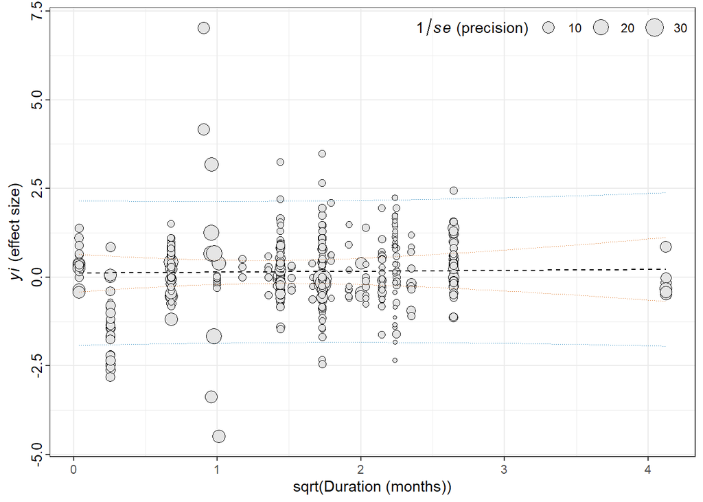

```r
fig_Durationmonths
```

```r
  # theme(text = element_text(size = 15),
  #       axis.text.y = element_text(size = 15))
```

## 6.6 Adding Mod Year (timeline bias)

```r
# Year
#checking the transform:
# qqnorm(meta$Year)
# qqline(meta$Year)
# qqnorm(sqrt(meta$Year))
# qqline(sqrt(meta$Year))
# qqnorm(log10(meta$Year))
# qqline(log10(meta$Year))
# qqnorm(log10(meta$Year+1))
# qqline(log10(meta$Year+1))
#the transformations don't change the data much, so leaving as is. ie- no transformation

rom.Year <- rma.mv(
  yi,
  V,
  mods = ~ scale(Year),
  random = list(
    ~ 1 | Study,
    ~ 1 | Exp_ID,
    ~ 1 | Effect_ID,
    ~ 1 | Parameter,
    ~ 1 | Species,
    ~ 1 | Phylogeny
  ),
  R = list(Phylogeny = cor),
  method = "REML",
  data = meta,
  control = list(optimizer = "optim")
)


forest(rom.Year)
```

```r
summary(rom.Year)

sum <- summary(rom.Year)
sum_I2 <- i2_ml(rom.Year, method = "ns")
sum_R2 <- r2_ml(rom.Year)

res.Year <- data.frame(
  effectname = attr(sum$beta, "dimnames")[[1]],
  beta = as.numeric(sum$beta),
  percentage_increase_or_decrease_on_Artificial = (exp(sum$beta)-1)*100,
  real.effect.value_exp_beta = exp(sum$beta),
  pval = sum$pval,
  ci.lb = sum$ci.lb,
  ci.ub = sum$ci.ub,
  I2_total = sum_I2[[1]] * 100,
  I2_study = sum_I2[[2]] * 100,
  I2_Exp_ID = sum_I2[[3]] * 100,
  I2_Effect_ID = sum_I2[[4]] * 100,
  I2_Parameter = sum_I2[[5]] * 100,
  I2_Species = sum_I2[[6]] * 100,
  I2_Phylogeny = sum_I2[[7]] * 100,
  R2_marginal_fixed = sum_R2[[1]] * 100,
  R2_conditional_fixed_random = sum_R2[[2]] * 100,
  Moderator_significance_stat = sum$QM,
  Moderator_significance_pval = sum$QMp,
  AIC = rom.Year$fit.stats$REML[3]
)

res_Year_df <- bind_rows(res.Year)
write.csv(res_Year_df, file = "./outputs/NIS/summ_Year.csv")


#####
## PLot of Year - Bubble plot
#####

pred_Year <- predict.rma(rom.Year)

# plotting

fig_year <-  meta %>%
  data.frame(
    .,
    ymin = pred_Year$ci.lb,
    ymax = pred_Year$ci.ub,
    ymin2 = pred_Year$cr.lb,
    ymax2 = pred_Year$cr.ub,
    pred = pred_Year$pred
  ) %>%
  ggplot(aes(
    x = Year,
    y = yi,
    #yi = effect size
    size = 1 / sqrt(vi / Replicates),
    # precision: 1/SE /was (1 / yi) + 3 - which doesn't make sense.
    # we can use sample size N (ie number of replicates)

  )) +
  geom_point(shape = 21, fill = "grey90") +
  #geom_ribbon(aes(ymin = ymin, ymax = ymax), fill = "#0072B2")  + # not quite sure why this does not work
  geom_smooth(
    aes(y = ymin2),
    method =  "loess",
    se = FALSE,
    lty =  "dotted",
    lwd = 0.25,
    colour = "#0072B2"
  ) +
  geom_smooth(
    aes(y = ymax2),
    method =  "loess",
    se = FALSE,
    lty = "dotted",
    lwd = 0.25,
    colour = "#0072B2"
  ) +
  geom_smooth(
    aes(y = ymin),
    method =  "loess",
    se = FALSE,
    lty = "dotted",
    lwd = 0.25,
    colour = "#D55E00"
  ) +
  geom_smooth(
    aes(y = ymax),
    method =  "loess",
    se = FALSE,
    lty = "dotted",
    lwd = 0.25,
    colour = "#D55E00"
  ) +
  geom_smooth(
    aes(y = pred),
    method =  "loess",
    se = FALSE,
    lty = "dashed",
    lwd = 0.5,
    colour = "black"
  ) +
  #ylim(-1, 2) + xlim(-0.05, 2) +
  #geom_abline(intercept = mr_Year$beta[[1]], slope = mr_Year$beta[[2]], alpha = 0.7, linetype = "dashed", size = 0.5) +
  labs(x = "Publication Year",
       y = expression(paste(italic(yi), " (effect size)")),
       size = expression(paste(italic(1 / se), " (precision)"))) +
  guides(fill = "none", colour = "none") +
  # themes
  theme_bw() +
  theme(legend.position = c(1, 1),
        legend.justification = c(1, 1)) +
  theme(legend.direction = "horizontal") +
  #theme(legend.background = element_rect(fill = "white", colour = "black")) +
  theme(legend.background = element_blank()) +
  theme(axis.text.y = element_text(
    size = 10,
    colour = "black",
    hjust = 0.5,
    angle = 90
  ))

fig_year  # looks good - no obvious divergence
```

```r
ggsave(filename = "./outputs/NIS/Bubble_year.tiff", dpi = plot_dpi)
```

Summary of results:

```r
res.Year %>%
  kable("html", digits = 3) %>%
  kable_styling("striped", position = "left") %>%
  scroll_box(width = "100%",
             height = "100")
```

|  | effectname | beta | percentage_increase_or_decrease_on_Artificial | real.effect.value_exp_beta | pval | ci.lb | ci.ub | I2_total | I2_study | I2_Exp_ID | I2_Effect_ID | I2_Parameter | I2_Species | I2_Phylogeny | R2_marginal_fixed | R2_conditional_fixed_random | Moderator_significance_stat | Moderator_significance_pval | AIC |
| --- | --- | --- | --- | --- | --- | --- | --- | --- | --- | --- | --- | --- | --- | --- | --- | --- | --- | --- | --- |
| intrcpt | intrcpt | 0.149 | 16.050 | 1.161 | 0.367 | -0.175 | 0.472 | 74.959 | 0.013 | 49.19 | 24.521 | 0 | 1.233 | 0.001 | 0.237 | 99.999 | 0.119 | 0.73 | 1513.188 |
| scale(Year) | scale(Year) | 0.049 | 5.023 | 1.050 | 0.730 | -0.230 | 0.328 | 74.959 | 0.013 | 49.19 | 24.521 | 0 | 1.233 | 0.001 | 0.237 | 99.999 | 0.119 | 0.73 | 1513.188 |

Plot for publication year

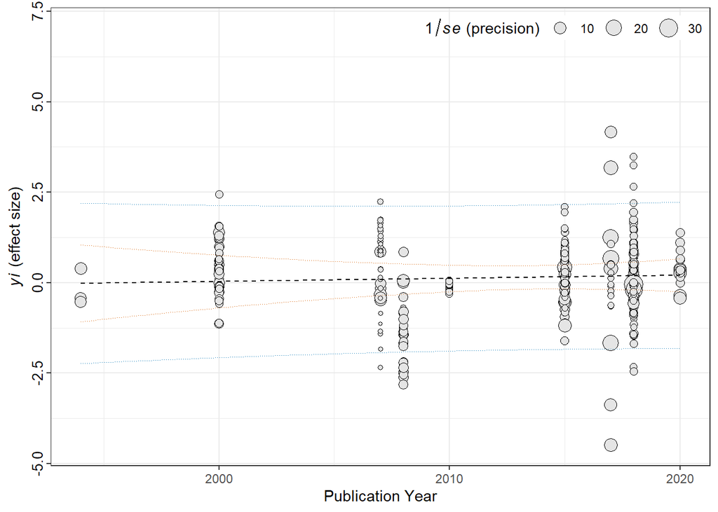

```r
fig_year
```

```r
  # theme(text = element_text(size = 15),
  #       axis.text.y = element_text(size = 15))
```

## 6.7 Adding Mod ALL MODERATORS

```r
rom.All <- rma.mv(
  yi,
  V,
  mods = ~ ControlTreatment +
    sqrt(Durationmonths) +
    scale(Year),
  random = list(
    ~ 1 | Study,
    ~ 1 | Exp_ID,
    ~ 1 | Effect_ID,
    ~ 1 | Parameter,
    ~ 1 | Species,
    ~ 1 | Phylogeny
  ),
  R = list(Phylogeny = cor),
  method = "REML",
  data = meta,
  control = list(optimizer = "optim")
)


sum <- summary(rom.All)
sum_I2 <- i2_ml(rom.All, method = "ns")
sum_R2 <- r2_ml(rom.All)


res.All <- data.frame(
  effectname = attr(sum$beta, "dimnames")[[1]],
  beta = as.numeric(sum$beta),
  percentage_increase_or_decrease_on_Artificial = (exp(sum$beta)-1)*100,
  real.effect.value_exp_beta = exp(sum$beta),
  pval = sum$pval,
  ci.lb = sum$ci.lb,
  ci.ub = sum$ci.ub,
  I2_total = sum_I2[[1]] * 100,
  I2_study = sum_I2[[2]] * 100,
  I2_Exp_ID = sum_I2[[3]] * 100,
  I2_Effect_ID = sum_I2[[4]] * 100,
  I2_Parameter = sum_I2[[5]] * 100,
  I2_Species = sum_I2[[6]] * 100,
  I2_Phylogeny = sum_I2[[7]] * 100,
  R2_marginal_fixed = sum_R2[[1]] * 100,
  R2_conditional_fixed_random = sum_R2[[2]] * 100,
  Moderator_significance_stat = sum$QM,
  Moderator_significance_pval = sum$QMp,
  AIC = rom.All$fit.stats$REML[3]
)

res.All <- bind_rows(res.All)
write.csv(res.All, file = "./outputs/NIS/summ_All.csv")
```

Summary of results:

```r
res.All %>%
  kable("html", digits = 3) %>%
  kable_styling("striped", position = "left") %>%
  scroll_box(width = "100%",
             height = "100")
```

|  | effectname | beta | percentage_increase_or_decrease_on_Artificial | real.effect.value_exp_beta | pval | ci.lb | ci.ub | I2_total | I2_study | I2_Exp_ID | I2_Effect_ID | I2_Parameter | I2_Species | I2_Phylogeny | R2_marginal_fixed | R2_conditional_fixed_random | Moderator_significance_stat | Moderator_significance_pval | AIC |
| --- | --- | --- | --- | --- | --- | --- | --- | --- | --- | --- | --- | --- | --- | --- | --- | --- | --- | --- | --- |
| intrcpt | intrcpt | 0.097 | 10.225 | 1.102 | 0.841 | -0.855 | 1.050 | 80.857 | 24.643 | 42.498 | 12.702 | 0.014 | 0.971 | 0.03 | 7.01 | 99.966 | 86.8 | 0 | 1441.833 |
| ControlTreatmentBiogenic_Polymer | ControlTreatmentBiogenic_Polymer | -0.003 | -0.255 | 0.997 | 0.993 | -0.582 | 0.577 | 80.857 | 24.643 | 42.498 | 12.702 | 0.014 | 0.971 | 0.03 | 7.01 | 99.966 | 86.8 | 0 | 1441.833 |
| ControlTreatmentRock_Clay | ControlTreatmentRock_Clay | 0.052 | 5.349 | 1.053 | 0.931 | -1.131 | 1.235 | 80.857 | 24.643 | 42.498 | 12.702 | 0.014 | 0.971 | 0.03 | 7.01 | 99.966 | 86.8 | 0 | 1441.833 |
| ControlTreatmentRock_Concrete | ControlTreatmentRock_Concrete | 0.100 | 10.541 | 1.105 | 0.759 | -0.541 | 0.741 | 80.857 | 24.643 | 42.498 | 12.702 | 0.014 | 0.971 | 0.03 | 7.01 | 99.966 | 86.8 | 0 | 1441.833 |
| ControlTreatmentRock_Metal | ControlTreatmentRock_Metal | 0.450 | 56.771 | 1.568 | 0.262 | -0.337 | 1.236 | 80.857 | 24.643 | 42.498 | 12.702 | 0.014 | 0.971 | 0.03 | 7.01 | 99.966 | 86.8 | 0 | 1441.833 |
| ControlTreatmentRock_Polymer | ControlTreatmentRock_Polymer | 0.279 | 32.164 | 1.322 | 0.380 | -0.344 | 0.902 | 80.857 | 24.643 | 42.498 | 12.702 | 0.014 | 0.971 | 0.03 | 7.01 | 99.966 | 86.8 | 0 | 1441.833 |
| ControlTreatmentWood_Concrete | ControlTreatmentWood_Concrete | 0.582 | 78.987 | 1.790 | 0.083 | -0.077 | 1.241 | 80.857 | 24.643 | 42.498 | 12.702 | 0.014 | 0.971 | 0.03 | 7.01 | 99.966 | 86.8 | 0 | 1441.833 |
| ControlTreatmentWood_Metal | ControlTreatmentWood_Metal | -1.766 | -82.906 | 0.171 | 0.000 | -2.593 | -0.940 | 80.857 | 24.643 | 42.498 | 12.702 | 0.014 | 0.971 | 0.03 | 7.01 | 99.966 | 86.8 | 0 | 1441.833 |
| ControlTreatmentWood_Polymer | ControlTreatmentWood_Polymer | 0.581 | 78.705 | 1.787 | 0.083 | -0.076 | 1.237 | 80.857 | 24.643 | 42.498 | 12.702 | 0.014 | 0.971 | 0.03 | 7.01 | 99.966 | 86.8 | 0 | 1441.833 |
| sqrt(Durationmonths) | sqrt(Durationmonths) | -0.032 | -3.162 | 0.968 | 0.871 | -0.421 | 0.357 | 80.857 | 24.643 | 42.498 | 12.702 | 0.014 | 0.971 | 0.03 | 7.01 | 99.966 | 86.8 | 0 | 1441.833 |
| scale(Year) | scale(Year) | -0.015 | -1.483 | 0.985 | 0.949 | -0.470 | 0.440 | 80.857 | 24.643 | 42.498 | 12.702 | 0.014 | 0.971 | 0.03 | 7.01 | 99.966 | 86.8 | 0 | 1441.833 |

##Full model comparisons Testing the robustness of all moderators.

```r
# https://stat.ethz.ch/pipermail/r-sig-mixed-models/2014q3/022608.html
# Viechtbauer, W. (2007). Accounting for heterogeneity via random-effects
# > models and moderator analyses in meta-analysis. Zeitschrift für
# > Psychologie / Journal of Psychology, 215(2), 104-121.
#https://stat.ethz.ch/pipermail/r-help/2011-August/285943.html
#
# explanation of tests of factors:
# http://www.metafor-project.org/doku.php/tips:testing_factors_lincoms

#summary(rom.All.noint)
summary(rom.All)
```

```
##
## Multivariate Meta-Analysis Model (k = 582; method: REML)
##
##    logLik   Deviance        AIC        BIC       AICc
## -703.9165  1407.8330  1441.8330  1515.7386  1442.9397
##
## Variance Components:
##
##             estim    sqrt  nlvls  fixed     factor    R
## sigma^2.1  0.4354  0.6599     11     no      Study   no
## sigma^2.2  0.7509  0.8665     46     no     Exp_ID   no
## sigma^2.3  0.2244  0.4737    582     no  Effect_ID   no
## sigma^2.4  0.0002  0.0156      2     no  Parameter   no
## sigma^2.5  0.0172  0.1310     21     no    Species   no
## sigma^2.6  0.0005  0.0228     21     no  Phylogeny  yes
##
## Test for Residual Heterogeneity:
## QE(df = 571) = 2043.9000, p-val < .0001
##
## Test of Moderators (coefficients 2:11):
## QM(df = 10) = 86.8001, p-val < .0001
##
## Model Results:
##
##                                   estimate      se     zval    pval    ci.lb
## intrcpt                             0.0974  0.4859   0.2003  0.8412  -0.8550
## ControlTreatmentBiogenic_Polymer   -0.0025  0.2959  -0.0086  0.9931  -0.5824
## ControlTreatmentRock_Clay           0.0521  0.6034   0.0864  0.9312  -1.1306
## ControlTreatmentRock_Concrete       0.1002  0.3271   0.3064  0.7593  -0.5410
## ControlTreatmentRock_Metal          0.4496  0.4011   1.1210  0.2623  -0.3365
## ControlTreatmentRock_Polymer        0.2789  0.3179   0.8771  0.3804  -0.3443
## ControlTreatmentWood_Concrete       0.5821  0.3363   1.7310  0.0835  -0.0770
## ControlTreatmentWood_Metal         -1.7664  0.4216  -4.1896  <.0001  -2.5928
## ControlTreatmentWood_Polymer        0.5806  0.3350   1.7332  0.0831  -0.0759
## sqrt(Durationmonths)               -0.0321  0.1985  -0.1618  0.8714  -0.4212
## scale(Year)                        -0.0149  0.2322  -0.0643  0.9487  -0.4700
##                                     ci.ub
## intrcpt                            1.0497
## ControlTreatmentBiogenic_Polymer   0.5773
## ControlTreatmentRock_Clay          1.2348
## ControlTreatmentRock_Concrete      0.7414
## ControlTreatmentRock_Metal         1.2358
## ControlTreatmentRock_Polymer       0.9020
## ControlTreatmentWood_Concrete      1.2413    .
## ControlTreatmentWood_Metal        -0.9401  ***
## ControlTreatmentWood_Polymer       1.2371    .
## sqrt(Durationmonths)               0.3570
## scale(Year)                        0.4401
##
## ---
## Signif. codes:  0 '***' 0.001 '**' 0.01 '*' 0.05 '.' 0.1 ' ' 1
```

```r
#
# treatment
summary(rom.ControlTreatment)
```

```
##
## Multivariate Meta-Analysis Model (k = 580; method: REML)
##
##    logLik   Deviance        AIC        BIC       AICc
## -707.8879  1415.7759  1443.7759  1504.6638  1444.5299
##
## Variance Components:
##
##             estim    sqrt  nlvls  fixed     factor    R
## sigma^2.1  0.3219  0.5674     11     no      Study   no
## sigma^2.2  0.7353  0.8575     46     no     Exp_ID   no
## sigma^2.3  0.2262  0.4757    580     no  Effect_ID   no
## sigma^2.4  0.0066  0.0815      2     no  Parameter   no
## sigma^2.5  0.0179  0.1340     21     no    Species   no
## sigma^2.6  0.0001  0.0076     21     no  Phylogeny  yes
##
## Test for Residual Heterogeneity:
## QE(df = 572) = 2098.2536, p-val < .0001
##
## Test of Moderators (coefficients 1:8):
## QM(df = 8) = 85.9748, p-val < .0001
##
## Model Results:
##
##                                   estimate      se     zval    pval    ci.lb
## ControlTreatmentBiogenic_Metal      0.0275  0.3961   0.0693  0.9447  -0.7488
## ControlTreatmentBiogenic_Polymer    0.0314  0.3173   0.0988  0.9213  -0.5905
## ControlTreatmentRock_Concrete       0.1393  0.2937   0.4743  0.6353  -0.4363
## ControlTreatmentRock_Metal          0.4593  0.4133   1.1111  0.2665  -0.3509
## ControlTreatmentRock_Polymer        0.3144  0.2977   1.0563  0.2909  -0.2690
## ControlTreatmentWood_Concrete       0.6240  0.2874   2.1714  0.0299   0.0607
## ControlTreatmentWood_Metal         -1.7070  0.3750  -4.5525  <.0001  -2.4420
## ControlTreatmentWood_Polymer        0.6237  0.2861   2.1799  0.0293   0.0629
##                                     ci.ub
## ControlTreatmentBiogenic_Metal     0.8038
## ControlTreatmentBiogenic_Polymer   0.6532
## ControlTreatmentRock_Concrete      0.7149
## ControlTreatmentRock_Metal         1.2694
## ControlTreatmentRock_Polymer       0.8979
## ControlTreatmentWood_Concrete      1.1872    *
## ControlTreatmentWood_Metal        -0.9721  ***
## ControlTreatmentWood_Polymer       1.1844    *
##
## ---
## Signif. codes:  0 '***' 0.001 '**' 0.01 '*' 0.05 '.' 0.1 ' ' 1
```

```r
anova(rom.All, btt = 2:9)
```

```
##
## Test of Moderators (coefficients 2:9):
## QM(df = 8) = 86.6793, p-val < .0001
```

```r
#-> remains significant in full model

#duration
summary(rom.Duration)
```

```
##
## Multivariate Meta-Analysis Model (k = 582; method: REML)
##
##    logLik   Deviance        AIC        BIC       AICc
## -748.8390  1497.6780  1513.6780  1548.5823  1513.9302
##
## Variance Components:
##
##             estim    sqrt  nlvls  fixed     factor    R
## sigma^2.1  0.0000  0.0036     11     no      Study   no
## sigma^2.2  0.6591  0.8118     46     no     Exp_ID   no
## sigma^2.3  0.3316  0.5759    582     no  Effect_ID   no
## sigma^2.4  0.0000  0.0010      2     no  Parameter   no
## sigma^2.5  0.0165  0.1284     21     no    Species   no
## sigma^2.6  0.0000  0.0010     21     no  Phylogeny  yes
##
## Test for Residual Heterogeneity:
## QE(df = 580) = 2525.2845, p-val < .0001
##
## Test of Moderators (coefficient 2):
## QM(df = 1) = 0.0250, p-val = 0.8743
##
## Model Results:
##
##                       estimate      se    zval    pval    ci.lb   ci.ub
## intrcpt                 0.1144  0.2741  0.4173  0.6764  -0.4228  0.6515
## sqrt(Durationmonths)    0.0249  0.1574  0.1582  0.8743  -0.2835  0.3333
##
## ---
## Signif. codes:  0 '***' 0.001 '**' 0.01 '*' 0.05 '.' 0.1 ' ' 1
```

```r
anova(rom.All, btt = 10)
```

```
##
## Test of Moderators (coefficient 10):
## QM(df = 1) = 0.0262, p-val = 0.8714
```

```r
#-> remains non-significant in full model

#year
summary(rom.Year)
```

```
##
## Multivariate Meta-Analysis Model (k = 582; method: REML)
##
##    logLik   Deviance        AIC        BIC       AICc
## -748.5939  1497.1877  1513.1877  1548.0919  1513.4399
##
## Variance Components:
##
##             estim    sqrt  nlvls  fixed     factor    R
## sigma^2.1  0.0002  0.0134     11     no      Study   no
## sigma^2.2  0.6644  0.8151     46     no     Exp_ID   no
## sigma^2.3  0.3312  0.5755    582     no  Effect_ID   no
## sigma^2.4  0.0000  0.0024      2     no  Parameter   no
## sigma^2.5  0.0166  0.1290     21     no    Species   no
## sigma^2.6  0.0000  0.0035     21     no  Phylogeny  yes
##
## Test for Residual Heterogeneity:
## QE(df = 580) = 2515.4467, p-val < .0001
##
## Test of Moderators (coefficient 2):
## QM(df = 1) = 0.1188, p-val = 0.7304
##
## Model Results:
##
##              estimate      se    zval    pval    ci.lb   ci.ub
## intrcpt        0.1489  0.1650  0.9022  0.3669  -0.1745  0.4722
## scale(Year)    0.0490  0.1422  0.3446  0.7304  -0.2297  0.3277
##
## ---
## Signif. codes:  0 '***' 0.001 '**' 0.01 '*' 0.05 '.' 0.1 ' ' 1
```

```r
anova(rom.All, btt = 11)
```

```
##
## Test of Moderators (coefficient 11):
## QM(df = 1) = 0.0041, p-val = 0.9487
```

```r
#-> remains non-significant in full model
```

# 7 PUBLICATION BIAS

This is important for testing whether only significant results were published.If this s the case, the results can be skewed in favor of significant results and create false positives or negatives - i.e. you’re not getting the full picture. This can be tested visually using a Funnel plot and then quantitatively using a trim and fill method. Both of the methods assume independence between effect sizes. If this is not the case, then the residuals from the full model can be used.

Funnel plot shows the effect size on the x axis and a measure of precision of the observed effect size on the y axis.

funnel() has std error on y by default.

Only significant moderators are included.

## 7.1 Funnel Plots

```r
#Simple model
jpeg("./outputs/NIS/funnel_simple.jpg",
     width = 600,
     height = 600)
par(cex = 1.4)
funnel(
  rom.simple,
  yaxis = "sei",
  level = c(90, 95, 99),
  shade = c("white",
            "gray55", "gray75"),
  refline = 0,
  legend = TRUE
)
dev.off()



#Model with significant moderators
rom.All.sign <- rma.mv(
  yi,
  V,
  mods = ~ ControlTreatment,
  random = list(
    ~ 1 | Study,
    ~ 1 | Exp_ID,
    ~ 1 | Effect_ID,
    ~ 1 | Parameter,
    ~ 1 | Species,
    ~ 1 | Phylogeny
  ),
  R = list(Phylogeny = cor),
  method = "REML",
  data = meta,
  control = list(optimizer = "optim")
)


jpeg("./outputs/NIS/funnel_All.sign.jpg",
     width = 600,
     height = 600)
par(cex = 1.4)
funnel(
  rom.All.sign,
  yaxis = "seinv",
  level = c(90, 95, 99),
  shade = c("white", "gray55", "gray75"),
  refline = 0,
  legend = TRUE
)
dev.off()

rom.All.sign.sei <- rma.mv(
  yi,
  V,
  mods = ~ ControlTreatment,
  random = list(
    ~ 1 | Study,
    ~ 1 | Exp_ID,
    ~ 1 | Effect_ID,
    ~ 1 | Parameter,
    ~ 1 | Species,
    ~ 1 | Phylogeny
  ),
  R = list(Phylogeny = cor),
  method = "REML",
  data = meta,
  control = list(optimizer = "optim")
)


jpeg("./outputs/NIS/funnel_All.sign.sei.jpg",
     width = 600,
     height = 600)
par(cex = 1.4)
funnel(
  rom.All.sign.sei,
  yaxis = "sei",
  level = c(90, 95, 99),
  shade = c("white", "gray55", "gray75"),
  refline = 0,
  legend = TRUE
)
dev.off()
```

## 7.2 Eggers Regression (significance of publication bias)

```r
### Eggers regression to test significance of publication bias (no intercept)
# testing whether any asymmetries in the funnel plots are significant

#Simple model
egger_reg_simple <- rma.mv (
  yi,
  V,
  mods = ~ sqrt(vi),
  random = list(
    ~ 1 | Study,
    ~ 1 | Exp_ID,
    ~ 1 | Effect_ID,
    ~ 1 | Parameter,
    ~ 1 | Species,
    ~ 1 | Phylogeny
  ),
  R = list(Phylogeny = cor),
  method = "REML",
  data = meta,
  control = list(optimizer = "optim")
)

summary(egger_reg_simple)


#Model with significant moderators
egger_reg_full.sign <- rma.mv (
  yi,
  V,
  mods = ~ sqrt(vi) +
    ControlTreatment,
  random = list(
    ~ 1 | Study,
    ~ 1 | Exp_ID,
    ~ 1 | Effect_ID,
    ~ 1 | Parameter,
    ~ 1 | Species,
    ~ 1 | Phylogeny
  ),
  R = list(Phylogeny = cor),
  method = "REML",
  data = meta,
  control = list(optimizer = "optim")
)

summary(egger_reg_full.sign)
```

# 8 SUMMARIES

## 8.1 Combined summary table

Creating a summary table of all the results summaries

```r
#get list of summaries
summaries <- mget(ls(pattern = "(res[^_])"))
#[^_] = NOT underscore (ie avoiding underscores)
summaries_df<-bind_rows(summaries, .id = "name")

write.csv(summaries_df, file = "./outputs/NIS/NIS_results.csv")
```